# SAMA AMR HABIB

## About dataset:

### EDA in a real business scenario

This case study aims to give us an idea of applying EDA in a real business scenario. In this case study, apart from applying the techniques that we have learnt in the EDA module, we will also develop a basic understanding of risk analytics in banking and financial services and understand how data is used to minimise the risk of losing money while lending to customers.

1. 0=Non_defaulter
2. 1= Defaulter

# Data import and basic exploration

```python
import pandas as pd
import numpy as np
import matplotlib.pyplot as plt
import seaborn as sns


# enable pandas to show all the items
pd.options.display.max_columns=None
pd.options.display.max_rows=None
```

```python
app=pd.read_csv("application_data.csv")
prev_app=pd.read_csv("previous_application.csv")
```

```python
app.head()
```

|  | SK_ID_CURR | TARGET | NAME_CONTRACT_TYPE | CODE_GENDER | FLAG_OWN_CAR | FLAG_OWN_REALTY | CNT_CHILDREN | AMT_INCOME_TOTAL | AMT_CREDIT | AMT_ANNUITY | AMT_GOODS_PRICE | NAME_TYPE_SUITE | NAME_INCOME_TYPE | NAME_EDUCATION_TYPE | NAME_FAMILY_STATUS | NAME_HOUSING_TYPE | REGION_POPULATION_RELATIVE | DAYS_BIRTH | DAYS_EMPLOYED | DAYS_REGISTRATION | DAYS_ID_PUBLISH | OWN_CAR_AGE | FLAG_MOBIL | FLAG_EMP_PHONE | FLAG_WORK_PHONE | FLAG_CONT_MOBILE | FLAG_PHONE | FLAG_EMAIL | OCCUPATION_TYPE | … |
| --- | --- | --- | --- | --- | --- | --- | --- | --- | --- | --- | --- | --- | --- | --- | --- | --- | --- | --- | --- | --- | --- | --- | --- | --- | --- | --- | --- | --- | --- | --- |
| 0 | 100002 | 1 | Cash loans | M | N | Y | 0 | 202500.0 | 406597.5 | 24700.5 | 351000.0 | Unaccompanied | Working | Secondary / secondary special | Single / not married | House / apartment | 0.018801 | -9461 | -637 | -3648.0 | -2120 | NaN | 1 | 1 | 0 | 1 | 1 | 0 | Laborers | … |
| 1 | 100003 | 0 | Cash loans | F | N | N | 0 | 270000.0 | 1293502.5 | 35698.5 | 1129500.0 | Family | State servant | Higher education | Married | House / apartment | 0.003541 | -16765 | -1188 | -1186.0 | -291 | NaN | 1 | 1 | 0 | 1 | 1 | 0 | Core staff | … |
| 2 | 100004 | 0 | Revolving loans | M | Y | Y | 0 | 67500.0 | 135000.0 | 6750.0 | 135000.0 | Unaccompanied | Working | Secondary / secondary special | Single / not married | House / apartment | 0.010032 | -19046 | -225 | -4260.0 | -2531 | 26.0 | 1 | 1 | 1 | 1 | 1 | 0 | Laborers | … |
| 3 | 100006 | 0 | Cash loans | F | N | Y | 0 | 135000.0 | 312682.5 | 29686.5 | 297000.0 | Unaccompanied | Working | Secondary / secondary special | Civil marriage | House / apartment | 0.008019 | -19005 | -3039 | -9833.0 | -2437 | NaN | 1 | 1 | 0 | 1 | 0 | 0 | Laborers | … |
| 4 | 100007 | 0 | Cash loans | M | N | Y | 0 | 121500.0 | 513000.0 | 21865.5 | 513000.0 | Unaccompanied | Working | Secondary / secondary special | Single / not married | House / apartment | 0.028663 | -19932 | -3038 | -4311.0 | -3458 | NaN | 1 | 1 | 0 | 1 | 0 | 0 | Core staff | … |

```python
prev_app.head()
```

|  | SK_ID_PREV | SK_ID_CURR | NAME_CONTRACT_TYPE | AMT_ANNUITY | AMT_APPLICATION | AMT_CREDIT | AMT_DOWN_PAYMENT | AMT_GOODS_PRICE | WEEKDAY_APPR_PROCESS_START | HOUR_APPR_PROCESS_START | FLAG_LAST_APPL_PER_CONTRACT | NFLAG_LAST_APPL_IN_DAY | RATE_DOWN_PAYMENT | RATE_INTEREST_PRIMARY | RATE_INTEREST_PRIVILEGED | NAME_CASH_LOAN_PURPOSE | NAME_CONTRACT_STATUS | DAYS_DECISION | NAME_PAYMENT_TYPE | CODE_REJECT_REASON | NAME_TYPE_SUITE | NAME_CLIENT_TYPE | NAME_GOODS_CATEGORY | NAME_PORTFOLIO | NAME_PRODUCT_TYPE | CHANNEL_TYPE | SELLERPLACE_AREA | NAME_SELLER_INDUSTRY | CNT_PAYMENT | … |
| --- | --- | --- | --- | --- | --- | --- | --- | --- | --- | --- | --- | --- | --- | --- | --- | --- | --- | --- | --- | --- | --- | --- | --- | --- | --- | --- | --- | --- | --- | --- |
| 0 | 2030495 | 271877 | Consumer loans | 1730.430 | 17145.0 | 17145.0 | 0.0 | 17145.0 | SATURDAY | 15 | Y | 1 | 0.0 | 0.182832 | 0.867336 | XAP | Approved | -73 | Cash through the bank | XAP | NaN | Repeater | Mobile | POS | XNA | Country-wide | 35 | Connectivity | 12.0 | … |
| 1 | 2802425 | 108129 | Cash loans | 25188.615 | 607500.0 | 679671.0 | NaN | 607500.0 | THURSDAY | 11 | Y | 1 | NaN | NaN | NaN | XNA | Approved | -164 | XNA | XAP | Unaccompanied | Repeater | XNA | Cash | x-sell | Contact center | -1 | XNA | 36.0 | … |
| 2 | 2523466 | 122040 | Cash loans | 15060.735 | 112500.0 | 136444.5 | NaN | 112500.0 | TUESDAY | 11 | Y | 1 | NaN | NaN | NaN | XNA | Approved | -301 | Cash through the bank | XAP | Spouse, partner | Repeater | XNA | Cash | x-sell | Credit and cash offices | -1 | XNA | 12.0 | … |
| 3 | 2819243 | 176158 | Cash loans | 47041.335 | 450000.0 | 470790.0 | NaN | 450000.0 | MONDAY | 7 | Y | 1 | NaN | NaN | NaN | XNA | Approved | -512 | Cash through the bank | XAP | NaN | Repeater | XNA | Cash | x-sell | Credit and cash offices | -1 | XNA | 12.0 | … |
| 4 | 1784265 | 202054 | Cash loans | 31924.395 | 337500.0 | 404055.0 | NaN | 337500.0 | THURSDAY | 9 | Y | 1 | NaN | NaN | NaN | Repairs | Refused | -781 | Cash through the bank | HC | NaN | Repeater | XNA | Cash | walk-in | Credit and cash offices | -1 | XNA | 24.0 | … |

# Feature Selection

```python
app.columns
```

```
Index(['SK_ID_CURR', 'TARGET', 'NAME_CONTRACT_TYPE', 'CODE_GENDER',
       'FLAG_OWN_CAR', 'FLAG_OWN_REALTY', 'CNT_CHILDREN', 'AMT_INCOME_TOTAL',
       'AMT_CREDIT', 'AMT_ANNUITY',
       ...
       'FLAG_DOCUMENT_18', 'FLAG_DOCUMENT_19', 'FLAG_DOCUMENT_20',
       'FLAG_DOCUMENT_21', 'AMT_REQ_CREDIT_BUREAU_HOUR',
       'AMT_REQ_CREDIT_BUREAU_DAY', 'AMT_REQ_CREDIT_BUREAU_WEEK',
       'AMT_REQ_CREDIT_BUREAU_MON', 'AMT_REQ_CREDIT_BUREAU_QRT',
       'AMT_REQ_CREDIT_BUREAU_YEAR'],
      dtype='object', length=122)
```

```python
app.shape
```

```
(307511, 122)
```

#### NULL DATA REMOVAL

```python
app.isnull().sum().sort_values()
```

```
SK_ID_CURR                           0
HOUR_APPR_PROCESS_START              0
REG_REGION_NOT_WORK_REGION           0
LIVE_REGION_NOT_WORK_REGION          0
REG_CITY_NOT_LIVE_CITY               0
REG_CITY_NOT_WORK_CITY               0
LIVE_CITY_NOT_WORK_CITY              0
ORGANIZATION_TYPE                    0
FLAG_DOCUMENT_21                     0
FLAG_DOCUMENT_20                     0
FLAG_DOCUMENT_19                     0
FLAG_DOCUMENT_18                     0
FLAG_DOCUMENT_17                     0
FLAG_DOCUMENT_16                     0
FLAG_DOCUMENT_15                     0
FLAG_DOCUMENT_14                     0
FLAG_DOCUMENT_13                     0
FLAG_DOCUMENT_12                     0
FLAG_DOCUMENT_11                     0
FLAG_DOCUMENT_10                     0
FLAG_DOCUMENT_9                      0
FLAG_DOCUMENT_8                      0
FLAG_DOCUMENT_7                      0
FLAG_DOCUMENT_6                      0
FLAG_DOCUMENT_5                      0
FLAG_DOCUMENT_4                      0
FLAG_DOCUMENT_3                      0
FLAG_DOCUMENT_2                      0
WEEKDAY_APPR_PROCESS_START           0
REGION_RATING_CLIENT_W_CITY          0
REG_REGION_NOT_LIVE_REGION           0
NAME_HOUSING_TYPE                    0
CNT_CHILDREN                         0
NAME_INCOME_TYPE                     0
NAME_EDUCATION_TYPE                  0
NAME_FAMILY_STATUS                   0
REGION_RATING_CLIENT                 0
REGION_POPULATION_RELATIVE           0
DAYS_BIRTH                           0
DAYS_EMPLOYED                        0
```

[output cut: 68 more lines]

```
YEARS_BUILD_MEDI                204488
FLOORSMIN_AVG                   208642
FLOORSMIN_MODE                  208642
FLOORSMIN_MEDI                  208642
LIVINGAPARTMENTS_AVG            210199
LIVINGAPARTMENTS_MODE           210199
LIVINGAPARTMENTS_MEDI           210199
FONDKAPREMONT_MODE              210295
NONLIVINGAPARTMENTS_AVG         213514
NONLIVINGAPARTMENTS_MEDI        213514
NONLIVINGAPARTMENTS_MODE        213514
COMMONAREA_MODE                 214865
COMMONAREA_AVG                  214865
COMMONAREA_MEDI                 214865
dtype: int64
```

```python
# lets put it in dataframe
msng_info =pd.DataFrame(app.isnull().sum().sort_values()).reset_index()
# reset index= ashan yb2a fe head ll columns f col esmo index w el tany kan 0
msng_info.rename(columns={'index':'col_name',0:'null_count'},inplace=True)
# hena we changed the names w we printed
msng_info.head()
```

|  | col_name | null_count |
| --- | --- | --- |
| 0 | SK_ID_CURR | 0 |
| 1 | HOUR_APPR_PROCESS_START | 0 |
| 2 | REG_REGION_NOT_WORK_REGION | 0 |
| 3 | LIVE_REGION_NOT_WORK_REGION | 0 |
| 4 | REG_CITY_NOT_LIVE_CITY | 0 |

```python
msng_info
```

|  | col_name | null_count |
| --- | --- | --- |
| 0 | SK_ID_CURR | 0 |
| 1 | HOUR_APPR_PROCESS_START | 0 |
| 2 | REG_REGION_NOT_WORK_REGION | 0 |
| 3 | LIVE_REGION_NOT_WORK_REGION | 0 |
| 4 | REG_CITY_NOT_LIVE_CITY | 0 |
| 5 | REG_CITY_NOT_WORK_CITY | 0 |
| 6 | LIVE_CITY_NOT_WORK_CITY | 0 |
| 7 | ORGANIZATION_TYPE | 0 |
| 8 | FLAG_DOCUMENT_21 | 0 |
| 9 | FLAG_DOCUMENT_20 | 0 |
| 10 | FLAG_DOCUMENT_19 | 0 |
| 11 | FLAG_DOCUMENT_18 | 0 |
| 12 | FLAG_DOCUMENT_17 | 0 |
| 13 | FLAG_DOCUMENT_16 | 0 |
| 14 | FLAG_DOCUMENT_15 | 0 |
| 15 | FLAG_DOCUMENT_14 | 0 |
| 16 | FLAG_DOCUMENT_13 | 0 |
| 17 | FLAG_DOCUMENT_12 | 0 |
| 18 | FLAG_DOCUMENT_11 | 0 |
| 19 | FLAG_DOCUMENT_10 | 0 |
| 20 | FLAG_DOCUMENT_9 | 0 |
| 21 | FLAG_DOCUMENT_8 | 0 |
| 22 | FLAG_DOCUMENT_7 | 0 |
| 23 | FLAG_DOCUMENT_6 | 0 |
| 24 | FLAG_DOCUMENT_5 | 0 |
| 25 | FLAG_DOCUMENT_4 | 0 |
| 26 | FLAG_DOCUMENT_3 | 0 |
| 27 | FLAG_DOCUMENT_2 | 0 |
| 28 | WEEKDAY_APPR_PROCESS_START | 0 |
| 29 | REGION_RATING_CLIENT_W_CITY | 0 |

[output cut: 92 more lines]

```python
# i want to see the percenatge of this missing data , i know the shape of the app file so ill use the columns
msng_info['msng_pct']=msng_info['null_count']/app.shape[0]*100
msng_info
```

|  | col_name | null_count | msng_pct |
| --- | --- | --- | --- |
| 0 | SK_ID_CURR | 0 | 0.000000 |
| 1 | HOUR_APPR_PROCESS_START | 0 | 0.000000 |
| 2 | REG_REGION_NOT_WORK_REGION | 0 | 0.000000 |
| 3 | LIVE_REGION_NOT_WORK_REGION | 0 | 0.000000 |
| 4 | REG_CITY_NOT_LIVE_CITY | 0 | 0.000000 |
| 5 | REG_CITY_NOT_WORK_CITY | 0 | 0.000000 |
| 6 | LIVE_CITY_NOT_WORK_CITY | 0 | 0.000000 |
| 7 | ORGANIZATION_TYPE | 0 | 0.000000 |
| 8 | FLAG_DOCUMENT_21 | 0 | 0.000000 |
| 9 | FLAG_DOCUMENT_20 | 0 | 0.000000 |
| 10 | FLAG_DOCUMENT_19 | 0 | 0.000000 |
| 11 | FLAG_DOCUMENT_18 | 0 | 0.000000 |
| 12 | FLAG_DOCUMENT_17 | 0 | 0.000000 |
| 13 | FLAG_DOCUMENT_16 | 0 | 0.000000 |
| 14 | FLAG_DOCUMENT_15 | 0 | 0.000000 |
| 15 | FLAG_DOCUMENT_14 | 0 | 0.000000 |
| 16 | FLAG_DOCUMENT_13 | 0 | 0.000000 |
| 17 | FLAG_DOCUMENT_12 | 0 | 0.000000 |
| 18 | FLAG_DOCUMENT_11 | 0 | 0.000000 |
| 19 | FLAG_DOCUMENT_10 | 0 | 0.000000 |
| 20 | FLAG_DOCUMENT_9 | 0 | 0.000000 |
| 21 | FLAG_DOCUMENT_8 | 0 | 0.000000 |
| 22 | FLAG_DOCUMENT_7 | 0 | 0.000000 |
| 23 | FLAG_DOCUMENT_6 | 0 | 0.000000 |
| 24 | FLAG_DOCUMENT_5 | 0 | 0.000000 |
| 25 | FLAG_DOCUMENT_4 | 0 | 0.000000 |
| 26 | FLAG_DOCUMENT_3 | 0 | 0.000000 |
| 27 | FLAG_DOCUMENT_2 | 0 | 0.000000 |
| 28 | WEEKDAY_APPR_PROCESS_START | 0 | 0.000000 |
| 29 | REGION_RATING_CLIENT_W_CITY | 0 | 0.000000 |

[output cut: 92 more lines]

```python
# then i want to export this info in an excel file
msng_info.to_excel('missing_info.xlsx',index=False)
msng_info.head()
```

|  | col_name | null_count | msng_pct |
| --- | --- | --- | --- |
| 0 | SK_ID_CURR | 0 | 0.0 |
| 1 | HOUR_APPR_PROCESS_START | 0 | 0.0 |
| 2 | REG_REGION_NOT_WORK_REGION | 0 | 0.0 |
| 3 | LIVE_REGION_NOT_WORK_REGION | 0 | 0.0 |
| 4 | REG_CITY_NOT_LIVE_CITY | 0 | 0.0 |

```python
# filter
msng_info[msng_info['msng_pct']>=40]
```

|  | col_name | null_count | msng_pct |
| --- | --- | --- | --- |
| 73 | EMERGENCYSTATE_MODE | 145755 | 47.398304 |
| 74 | TOTALAREA_MODE | 148431 | 48.268517 |
| 75 | YEARS_BEGINEXPLUATATION_MODE | 150007 | 48.781019 |
| 76 | YEARS_BEGINEXPLUATATION_AVG | 150007 | 48.781019 |
| 77 | YEARS_BEGINEXPLUATATION_MEDI | 150007 | 48.781019 |
| 78 | FLOORSMAX_AVG | 153020 | 49.760822 |
| 79 | FLOORSMAX_MEDI | 153020 | 49.760822 |
| 80 | FLOORSMAX_MODE | 153020 | 49.760822 |
| 81 | HOUSETYPE_MODE | 154297 | 50.176091 |
| 82 | LIVINGAREA_AVG | 154350 | 50.193326 |
| 83 | LIVINGAREA_MODE | 154350 | 50.193326 |
| 84 | LIVINGAREA_MEDI | 154350 | 50.193326 |
| 85 | ENTRANCES_AVG | 154828 | 50.348768 |
| 86 | ENTRANCES_MODE | 154828 | 50.348768 |
| 87 | ENTRANCES_MEDI | 154828 | 50.348768 |
| 88 | APARTMENTS_MEDI | 156061 | 50.749729 |
| 89 | APARTMENTS_AVG | 156061 | 50.749729 |
| 90 | APARTMENTS_MODE | 156061 | 50.749729 |
| 91 | WALLSMATERIAL_MODE | 156341 | 50.840783 |
| 92 | ELEVATORS_MEDI | 163891 | 53.295980 |
| 93 | ELEVATORS_AVG | 163891 | 53.295980 |
| 94 | ELEVATORS_MODE | 163891 | 53.295980 |
| 95 | NONLIVINGAREA_MODE | 169682 | 55.179164 |
| 96 | NONLIVINGAREA_AVG | 169682 | 55.179164 |
| 97 | NONLIVINGAREA_MEDI | 169682 | 55.179164 |
| 98 | EXT_SOURCE_1 | 173378 | 56.381073 |
| 99 | BASEMENTAREA_MODE | 179943 | 58.515956 |
| 100 | BASEMENTAREA_AVG | 179943 | 58.515956 |
| 101 | BASEMENTAREA_MEDI | 179943 | 58.515956 |
| 102 | LANDAREA_MEDI | 182590 | 59.376738 |
| 103 | LANDAREA_AVG | 182590 | 59.376738 |
| 104 | LANDAREA_MODE | 182590 | 59.376738 |
| 105 | OWN_CAR_AGE | 202929 | 65.990810 |
| 106 | YEARS_BUILD_MODE | 204488 | 66.497784 |
| 107 | YEARS_BUILD_AVG | 204488 | 66.497784 |
| 108 | YEARS_BUILD_MEDI | 204488 | 66.497784 |
| 109 | FLOORSMIN_AVG | 208642 | 67.848630 |
| 110 | FLOORSMIN_MODE | 208642 | 67.848630 |
| 111 | FLOORSMIN_MEDI | 208642 | 67.848630 |
| 112 | LIVINGAPARTMENTS_AVG | 210199 | 68.354953 |
| 113 | LIVINGAPARTMENTS_MODE | 210199 | 68.354953 |
| 114 | LIVINGAPARTMENTS_MEDI | 210199 | 68.354953 |
| 115 | FONDKAPREMONT_MODE | 210295 | 68.386172 |
| 116 | NONLIVINGAPARTMENTS_AVG | 213514 | 69.432963 |
| 117 | NONLIVINGAPARTMENTS_MEDI | 213514 | 69.432963 |
| 118 | NONLIVINGAPARTMENTS_MODE | 213514 | 69.432963 |
| 119 | COMMONAREA_MODE | 214865 | 69.872297 |
| 120 | COMMONAREA_AVG | 214865 | 69.872297 |
| 121 | COMMONAREA_MEDI | 214865 | 69.872297 |

```python
# filter & put it in list
msng_col = msng_info[msng_info['msng_pct']>=40]['col_name'].to_list()
msng_col
```

```
['EMERGENCYSTATE_MODE',
 'TOTALAREA_MODE',
 'YEARS_BEGINEXPLUATATION_MODE',
 'YEARS_BEGINEXPLUATATION_AVG',
 'YEARS_BEGINEXPLUATATION_MEDI',
 'FLOORSMAX_AVG',
 'FLOORSMAX_MEDI',
 'FLOORSMAX_MODE',
 'HOUSETYPE_MODE',
 'LIVINGAREA_AVG',
 'LIVINGAREA_MODE',
 'LIVINGAREA_MEDI',
 'ENTRANCES_AVG',
 'ENTRANCES_MODE',
 'ENTRANCES_MEDI',
 'APARTMENTS_MEDI',
 'APARTMENTS_AVG',
 'APARTMENTS_MODE',
 'WALLSMATERIAL_MODE',
 'ELEVATORS_MEDI',
 'ELEVATORS_AVG',
 'ELEVATORS_MODE',
 'NONLIVINGAREA_MODE',
 'NONLIVINGAREA_AVG',
 'NONLIVINGAREA_MEDI',
 'EXT_SOURCE_1',
 'BASEMENTAREA_MODE',
 'BASEMENTAREA_AVG',
 'BASEMENTAREA_MEDI',
 'LANDAREA_MEDI',
 'LANDAREA_AVG',
 'LANDAREA_MODE',
 'OWN_CAR_AGE',
 'YEARS_BUILD_MODE',
 'YEARS_BUILD_AVG',
 'YEARS_BUILD_MEDI',
 'FLOORSMIN_AVG',
 'FLOORSMIN_MODE',
 'FLOORSMIN_MEDI',
 'LIVINGAPARTMENTS_AVG',
 'LIVINGAPARTMENTS_MODE',
 'LIVINGAPARTMENTS_MEDI',
 'FONDKAPREMONT_MODE',
 'NONLIVINGAPARTMENTS_AVG',
 'NONLIVINGAPARTMENTS_MEDI',
 'NONLIVINGAPARTMENTS_MODE',
 'COMMONAREA_MODE',
 'COMMONAREA_AVG',
 'COMMONAREA_MEDI']
```

```python
len(msng_col)
```

```
49
```

```python
# remove missing data more than 40%
app_msng_rmvd=app.drop(labels=msng_col,axis=1)
app_msng_rmvd.shape
```

```
(307511, 73)
```

```python
app_msng_rmvd.head()
```

|  | SK_ID_CURR | TARGET | NAME_CONTRACT_TYPE | CODE_GENDER | FLAG_OWN_CAR | FLAG_OWN_REALTY | CNT_CHILDREN | AMT_INCOME_TOTAL | AMT_CREDIT | AMT_ANNUITY | AMT_GOODS_PRICE | NAME_TYPE_SUITE | NAME_INCOME_TYPE | NAME_EDUCATION_TYPE | NAME_FAMILY_STATUS | NAME_HOUSING_TYPE | REGION_POPULATION_RELATIVE | DAYS_BIRTH | DAYS_EMPLOYED | DAYS_REGISTRATION | DAYS_ID_PUBLISH | FLAG_MOBIL | FLAG_EMP_PHONE | FLAG_WORK_PHONE | FLAG_CONT_MOBILE | FLAG_PHONE | FLAG_EMAIL | OCCUPATION_TYPE | CNT_FAM_MEMBERS | … |
| --- | --- | --- | --- | --- | --- | --- | --- | --- | --- | --- | --- | --- | --- | --- | --- | --- | --- | --- | --- | --- | --- | --- | --- | --- | --- | --- | --- | --- | --- | --- |
| 0 | 100002 | 1 | Cash loans | M | N | Y | 0 | 202500.0 | 406597.5 | 24700.5 | 351000.0 | Unaccompanied | Working | Secondary / secondary special | Single / not married | House / apartment | 0.018801 | -9461 | -637 | -3648.0 | -2120 | 1 | 1 | 0 | 1 | 1 | 0 | Laborers | 1.0 | … |
| 1 | 100003 | 0 | Cash loans | F | N | N | 0 | 270000.0 | 1293502.5 | 35698.5 | 1129500.0 | Family | State servant | Higher education | Married | House / apartment | 0.003541 | -16765 | -1188 | -1186.0 | -291 | 1 | 1 | 0 | 1 | 1 | 0 | Core staff | 2.0 | … |
| 2 | 100004 | 0 | Revolving loans | M | Y | Y | 0 | 67500.0 | 135000.0 | 6750.0 | 135000.0 | Unaccompanied | Working | Secondary / secondary special | Single / not married | House / apartment | 0.010032 | -19046 | -225 | -4260.0 | -2531 | 1 | 1 | 1 | 1 | 1 | 0 | Laborers | 1.0 | … |
| 3 | 100006 | 0 | Cash loans | F | N | Y | 0 | 135000.0 | 312682.5 | 29686.5 | 297000.0 | Unaccompanied | Working | Secondary / secondary special | Civil marriage | House / apartment | 0.008019 | -19005 | -3039 | -9833.0 | -2437 | 1 | 1 | 0 | 1 | 0 | 0 | Laborers | 2.0 | … |
| 4 | 100007 | 0 | Cash loans | M | N | Y | 0 | 121500.0 | 513000.0 | 21865.5 | 513000.0 | Unaccompanied | Working | Secondary / secondary special | Single / not married | House / apartment | 0.028663 | -19932 | -3038 | -4311.0 | -3458 | 1 | 1 | 0 | 1 | 0 | 0 | Core staff | 1.0 | … |

#### FLAG COLUMNS

```python
# Now we have multiple flag columns lets understand them

flag_col= []

for col in app_msng_rmvd.columns:
    if col.startswith('FLAG_'):
        flag_col.append(col)

flag_col
```

```
['FLAG_OWN_CAR',
 'FLAG_OWN_REALTY',
 'FLAG_MOBIL',
 'FLAG_EMP_PHONE',
 'FLAG_WORK_PHONE',
 'FLAG_CONT_MOBILE',
 'FLAG_PHONE',
 'FLAG_EMAIL',
 'FLAG_DOCUMENT_2',
 'FLAG_DOCUMENT_3',
 'FLAG_DOCUMENT_4',
 'FLAG_DOCUMENT_5',
 'FLAG_DOCUMENT_6',
 'FLAG_DOCUMENT_7',
 'FLAG_DOCUMENT_8',
 'FLAG_DOCUMENT_9',
 'FLAG_DOCUMENT_10',
 'FLAG_DOCUMENT_11',
 'FLAG_DOCUMENT_12',
 'FLAG_DOCUMENT_13',
 'FLAG_DOCUMENT_14',
 'FLAG_DOCUMENT_15',
 'FLAG_DOCUMENT_16',
 'FLAG_DOCUMENT_17',
 'FLAG_DOCUMENT_18',
 'FLAG_DOCUMENT_19',
 'FLAG_DOCUMENT_20',
 'FLAG_DOCUMENT_21']
```

```python
len(flag_col)
```

```
28
```

```python
app_msng_rmvd[flag_col+['TARGET']].head()
```

|  | FLAG_OWN_CAR | FLAG_OWN_REALTY | FLAG_MOBIL | FLAG_EMP_PHONE | FLAG_WORK_PHONE | FLAG_CONT_MOBILE | FLAG_PHONE | FLAG_EMAIL | FLAG_DOCUMENT_2 | FLAG_DOCUMENT_3 | FLAG_DOCUMENT_4 | FLAG_DOCUMENT_5 | FLAG_DOCUMENT_6 | FLAG_DOCUMENT_7 | FLAG_DOCUMENT_8 | FLAG_DOCUMENT_9 | FLAG_DOCUMENT_10 | FLAG_DOCUMENT_11 | FLAG_DOCUMENT_12 | FLAG_DOCUMENT_13 | FLAG_DOCUMENT_14 | FLAG_DOCUMENT_15 | FLAG_DOCUMENT_16 | FLAG_DOCUMENT_17 | FLAG_DOCUMENT_18 | FLAG_DOCUMENT_19 | FLAG_DOCUMENT_20 | FLAG_DOCUMENT_21 | TARGET |
| --- | --- | --- | --- | --- | --- | --- | --- | --- | --- | --- | --- | --- | --- | --- | --- | --- | --- | --- | --- | --- | --- | --- | --- | --- | --- | --- | --- | --- | --- |
| 0 | N | Y | 1 | 1 | 0 | 1 | 1 | 0 | 0 | 1 | 0 | 0 | 0 | 0 | 0 | 0 | 0 | 0 | 0 | 0 | 0 | 0 | 0 | 0 | 0 | 0 | 0 | 0 | 1 |
| 1 | N | N | 1 | 1 | 0 | 1 | 1 | 0 | 0 | 1 | 0 | 0 | 0 | 0 | 0 | 0 | 0 | 0 | 0 | 0 | 0 | 0 | 0 | 0 | 0 | 0 | 0 | 0 | 0 |
| 2 | Y | Y | 1 | 1 | 1 | 1 | 1 | 0 | 0 | 0 | 0 | 0 | 0 | 0 | 0 | 0 | 0 | 0 | 0 | 0 | 0 | 0 | 0 | 0 | 0 | 0 | 0 | 0 | 0 |
| 3 | N | Y | 1 | 1 | 0 | 1 | 0 | 0 | 0 | 1 | 0 | 0 | 0 | 0 | 0 | 0 | 0 | 0 | 0 | 0 | 0 | 0 | 0 | 0 | 0 | 0 | 0 | 0 | 0 |
| 4 | N | Y | 1 | 1 | 0 | 1 | 0 | 0 | 0 | 0 | 0 | 0 | 0 | 0 | 1 | 0 | 0 | 0 | 0 | 0 | 0 | 0 | 0 | 0 | 0 | 0 | 0 | 0 | 0 |

```python
# put it in a dataframe
flag_tgt_col = app_msng_rmvd[flag_col+['TARGET']]
flag_tgt_col.head()
```

|  | FLAG_OWN_CAR | FLAG_OWN_REALTY | FLAG_MOBIL | FLAG_EMP_PHONE | FLAG_WORK_PHONE | FLAG_CONT_MOBILE | FLAG_PHONE | FLAG_EMAIL | FLAG_DOCUMENT_2 | FLAG_DOCUMENT_3 | FLAG_DOCUMENT_4 | FLAG_DOCUMENT_5 | FLAG_DOCUMENT_6 | FLAG_DOCUMENT_7 | FLAG_DOCUMENT_8 | FLAG_DOCUMENT_9 | FLAG_DOCUMENT_10 | FLAG_DOCUMENT_11 | FLAG_DOCUMENT_12 | FLAG_DOCUMENT_13 | FLAG_DOCUMENT_14 | FLAG_DOCUMENT_15 | FLAG_DOCUMENT_16 | FLAG_DOCUMENT_17 | FLAG_DOCUMENT_18 | FLAG_DOCUMENT_19 | FLAG_DOCUMENT_20 | FLAG_DOCUMENT_21 | TARGET |
| --- | --- | --- | --- | --- | --- | --- | --- | --- | --- | --- | --- | --- | --- | --- | --- | --- | --- | --- | --- | --- | --- | --- | --- | --- | --- | --- | --- | --- | --- |
| 0 | N | Y | 1 | 1 | 0 | 1 | 1 | 0 | 0 | 1 | 0 | 0 | 0 | 0 | 0 | 0 | 0 | 0 | 0 | 0 | 0 | 0 | 0 | 0 | 0 | 0 | 0 | 0 | 1 |
| 1 | N | N | 1 | 1 | 0 | 1 | 1 | 0 | 0 | 1 | 0 | 0 | 0 | 0 | 0 | 0 | 0 | 0 | 0 | 0 | 0 | 0 | 0 | 0 | 0 | 0 | 0 | 0 | 0 |
| 2 | Y | Y | 1 | 1 | 1 | 1 | 1 | 0 | 0 | 0 | 0 | 0 | 0 | 0 | 0 | 0 | 0 | 0 | 0 | 0 | 0 | 0 | 0 | 0 | 0 | 0 | 0 | 0 | 0 |
| 3 | N | Y | 1 | 1 | 0 | 1 | 0 | 0 | 0 | 1 | 0 | 0 | 0 | 0 | 0 | 0 | 0 | 0 | 0 | 0 | 0 | 0 | 0 | 0 | 0 | 0 | 0 | 0 | 0 |
| 4 | N | Y | 1 | 1 | 0 | 1 | 0 | 0 | 0 | 0 | 0 | 0 | 0 | 0 | 1 | 0 | 0 | 0 | 0 | 0 | 0 | 0 | 0 | 0 | 0 | 0 | 0 | 0 | 0 |

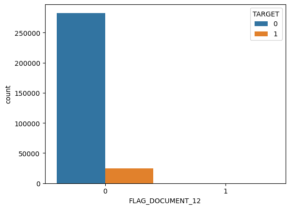

```python
# Now we want to know the relation / distribuation between TARGET col(defaulter or not ) and flag columns

sns.countplot(data=flag_tgt_col,x='FLAG_DOCUMENT_12',hue='TARGET')


# 0=Non_defaulter
# 1= Defaulter
```

NOTE:Most custmoers that didnt submit flag 12 are non defaulters

[figure not shown]

```python
# we used I and ENUMERATE : it will print the list and index position
# 7 rows 4 columns

for i, col in enumerate(flag_col):
    plt.subplot(7,4,i+1)
    sns.countplot(data=flag_tgt_col,x=col,hue='TARGET')
```

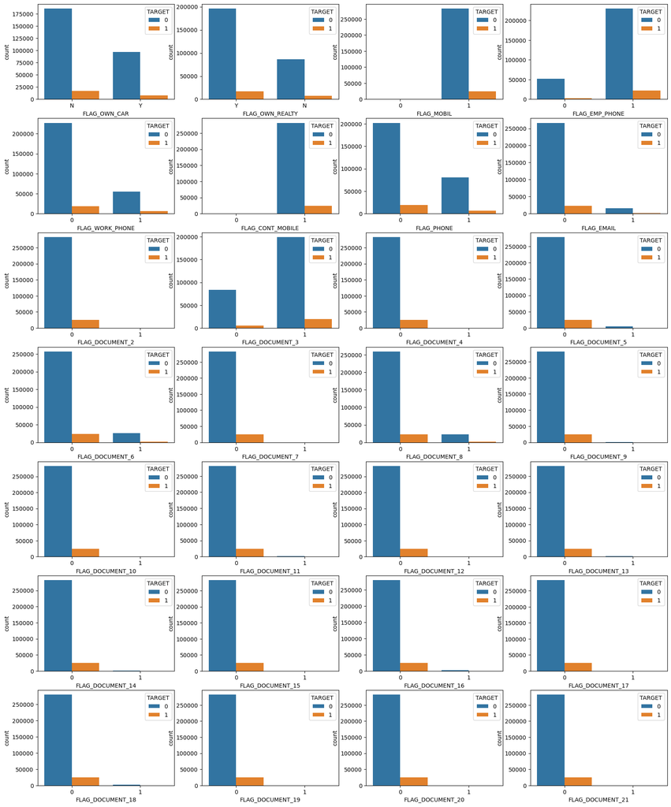

```python
plt.figure(figsize=(20,25))

for i, col in enumerate(flag_col):
    plt.subplot(7,4,i+1)
    sns.countplot(data=flag_tgt_col,x=col,hue='TARGET')
```

Conclude : that most customers who arent submitting documents are NON DEFAULTERS

```python
# We now want to see correlation of these variables with the target (n,y ON THE GRAPHS )

flg_corr=['FLAG_OWN_CAR','FLAG_OWN_REALTY','FLAG_MOBIL','FLAG_EMP_PHONE','FLAG_WORK_PHONE','FLAG_CONT_MOBILE',
          'FLAG_PHONE','FLAG_EMAIL','TARGET']
flag_corr_df= app_msng_rmvd[flg_corr]
flag_corr_df.head()
```

|  | FLAG_OWN_CAR | FLAG_OWN_REALTY | FLAG_MOBIL | FLAG_EMP_PHONE | FLAG_WORK_PHONE | FLAG_CONT_MOBILE | FLAG_PHONE | FLAG_EMAIL | TARGET |
| --- | --- | --- | --- | --- | --- | --- | --- | --- | --- |
| 0 | N | Y | 1 | 1 | 0 | 1 | 1 | 0 | 1 |
| 1 | N | N | 1 | 1 | 0 | 1 | 1 | 0 | 0 |
| 2 | Y | Y | 1 | 1 | 1 | 1 | 1 | 0 | 0 |
| 3 | N | Y | 1 | 1 | 0 | 1 | 0 | 0 | 0 |
| 4 | N | Y | 1 | 1 | 0 | 1 | 0 | 0 | 0 |

```python
flag_corr_df.groupby(['FLAG_OWN_CAR']).size()
```

```
FLAG_OWN_CAR
N    202924
Y    104587
dtype: int64
```

```python
flag_corr_df.groupby(['FLAG_OWN_REALTY']).size()
```

```
FLAG_OWN_REALTY
N     94199
Y    213312
dtype: int64
```

```python
flag_corr_df['FLAG_OWN_CAR']=flag_corr_df['FLAG_OWN_CAR'].replace({'N':0,'Y':1})
flag_corr_df['FLAG_OWN_REALTY']=flag_corr_df['FLAG_OWN_REALTY'].replace({'N':0,'Y':1})


flag_corr_df.groupby(['FLAG_OWN_CAR']).size()
```

```
FLAG_OWN_CAR
0    202924
1    104587
dtype: int64
```

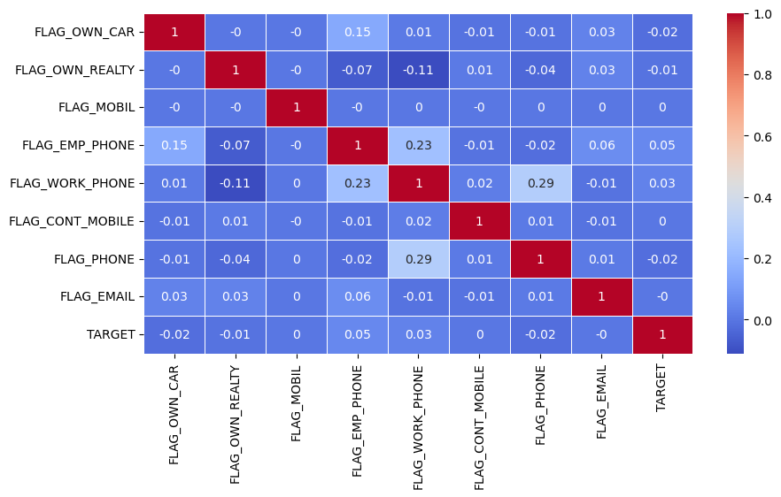

```python
# FIND CORRELATION OF THESE COLUMNS(flg_corr) WITHT HE TARGET COLUMN
# Put it in dataframe to apply heatmap on it
# Calculate correlation
corr_df= round(flag_corr_df.corr(), 2)

plt.figure(figsize=(10,5))
sns.heatmap(corr_df, cmap='coolwarm',linewidths=.5,annot=True)
# coolwarm just changed the color
```

Note: FLAG_OWN_CAR,FLAG_OWN_REALITY: They dont have very good relation with the target variable SO WE SHOULD DROP THEM OFF NOW

```python
app_flag_rmvd=app_msng_rmvd.drop(labels = ['FLAG_OWN_CAR','FLAG_OWN_REALTY','FLAG_MOBIL','FLAG_EMP_PHONE','FLAG_WORK_PHONE','FLAG_CONT_MOBILE',
          'FLAG_PHONE','FLAG_EMAIL'],axis=1)


app_flag_rmvd.shape
```

```
(307511, 65)
```

```python
app_flag_rmvd.head()
```

|  | SK_ID_CURR | TARGET | NAME_CONTRACT_TYPE | CODE_GENDER | CNT_CHILDREN | AMT_INCOME_TOTAL | AMT_CREDIT | AMT_ANNUITY | AMT_GOODS_PRICE | NAME_TYPE_SUITE | NAME_INCOME_TYPE | NAME_EDUCATION_TYPE | NAME_FAMILY_STATUS | NAME_HOUSING_TYPE | REGION_POPULATION_RELATIVE | DAYS_BIRTH | DAYS_EMPLOYED | DAYS_REGISTRATION | DAYS_ID_PUBLISH | OCCUPATION_TYPE | CNT_FAM_MEMBERS | REGION_RATING_CLIENT | REGION_RATING_CLIENT_W_CITY | WEEKDAY_APPR_PROCESS_START | HOUR_APPR_PROCESS_START | REG_REGION_NOT_LIVE_REGION | REG_REGION_NOT_WORK_REGION | LIVE_REGION_NOT_WORK_REGION | REG_CITY_NOT_LIVE_CITY | … |
| --- | --- | --- | --- | --- | --- | --- | --- | --- | --- | --- | --- | --- | --- | --- | --- | --- | --- | --- | --- | --- | --- | --- | --- | --- | --- | --- | --- | --- | --- | --- |
| 0 | 100002 | 1 | Cash loans | M | 0 | 202500.0 | 406597.5 | 24700.5 | 351000.0 | Unaccompanied | Working | Secondary / secondary special | Single / not married | House / apartment | 0.018801 | -9461 | -637 | -3648.0 | -2120 | Laborers | 1.0 | 2 | 2 | WEDNESDAY | 10 | 0 | 0 | 0 | 0 | … |
| 1 | 100003 | 0 | Cash loans | F | 0 | 270000.0 | 1293502.5 | 35698.5 | 1129500.0 | Family | State servant | Higher education | Married | House / apartment | 0.003541 | -16765 | -1188 | -1186.0 | -291 | Core staff | 2.0 | 1 | 1 | MONDAY | 11 | 0 | 0 | 0 | 0 | … |
| 2 | 100004 | 0 | Revolving loans | M | 0 | 67500.0 | 135000.0 | 6750.0 | 135000.0 | Unaccompanied | Working | Secondary / secondary special | Single / not married | House / apartment | 0.010032 | -19046 | -225 | -4260.0 | -2531 | Laborers | 1.0 | 2 | 2 | MONDAY | 9 | 0 | 0 | 0 | 0 | … |
| 3 | 100006 | 0 | Cash loans | F | 0 | 135000.0 | 312682.5 | 29686.5 | 297000.0 | Unaccompanied | Working | Secondary / secondary special | Civil marriage | House / apartment | 0.008019 | -19005 | -3039 | -9833.0 | -2437 | Laborers | 2.0 | 2 | 2 | WEDNESDAY | 17 | 0 | 0 | 0 | 0 | … |
| 4 | 100007 | 0 | Cash loans | M | 0 | 121500.0 | 513000.0 | 21865.5 | 513000.0 | Unaccompanied | Working | Secondary / secondary special | Single / not married | House / apartment | 0.028663 | -19932 | -3038 | -4311.0 | -3458 | Core staff | 1.0 | 2 | 2 | THURSDAY | 11 | 0 | 0 | 0 | 0 | … |

```python
flag_col
```

```
['FLAG_OWN_CAR',
 'FLAG_OWN_REALTY',
 'FLAG_MOBIL',
 'FLAG_EMP_PHONE',
 'FLAG_WORK_PHONE',
 'FLAG_CONT_MOBILE',
 'FLAG_PHONE',
 'FLAG_EMAIL',
 'FLAG_DOCUMENT_2',
 'FLAG_DOCUMENT_3',
 'FLAG_DOCUMENT_4',
 'FLAG_DOCUMENT_5',
 'FLAG_DOCUMENT_6',
 'FLAG_DOCUMENT_7',
 'FLAG_DOCUMENT_8',
 'FLAG_DOCUMENT_9',
 'FLAG_DOCUMENT_10',
 'FLAG_DOCUMENT_11',
 'FLAG_DOCUMENT_12',
 'FLAG_DOCUMENT_13',
 'FLAG_DOCUMENT_14',
 'FLAG_DOCUMENT_15',
 'FLAG_DOCUMENT_16',
 'FLAG_DOCUMENT_17',
 'FLAG_DOCUMENT_18',
 'FLAG_DOCUMENT_19',
 'FLAG_DOCUMENT_20',
 'FLAG_DOCUMENT_21']
```

```python
app_flag_rmvd=app_msng_rmvd.drop(labels =flag_col,axis=1)


app_flag_rmvd.shape
```

```
(307511, 45)
```

```python
app_flag_rmvd.head()
```

|  | SK_ID_CURR | TARGET | NAME_CONTRACT_TYPE | CODE_GENDER | CNT_CHILDREN | AMT_INCOME_TOTAL | AMT_CREDIT | AMT_ANNUITY | AMT_GOODS_PRICE | NAME_TYPE_SUITE | NAME_INCOME_TYPE | NAME_EDUCATION_TYPE | NAME_FAMILY_STATUS | NAME_HOUSING_TYPE | REGION_POPULATION_RELATIVE | DAYS_BIRTH | DAYS_EMPLOYED | DAYS_REGISTRATION | DAYS_ID_PUBLISH | OCCUPATION_TYPE | CNT_FAM_MEMBERS | REGION_RATING_CLIENT | REGION_RATING_CLIENT_W_CITY | WEEKDAY_APPR_PROCESS_START | HOUR_APPR_PROCESS_START | REG_REGION_NOT_LIVE_REGION | REG_REGION_NOT_WORK_REGION | LIVE_REGION_NOT_WORK_REGION | REG_CITY_NOT_LIVE_CITY | … |
| --- | --- | --- | --- | --- | --- | --- | --- | --- | --- | --- | --- | --- | --- | --- | --- | --- | --- | --- | --- | --- | --- | --- | --- | --- | --- | --- | --- | --- | --- | --- |
| 0 | 100002 | 1 | Cash loans | M | 0 | 202500.0 | 406597.5 | 24700.5 | 351000.0 | Unaccompanied | Working | Secondary / secondary special | Single / not married | House / apartment | 0.018801 | -9461 | -637 | -3648.0 | -2120 | Laborers | 1.0 | 2 | 2 | WEDNESDAY | 10 | 0 | 0 | 0 | 0 | … |
| 1 | 100003 | 0 | Cash loans | F | 0 | 270000.0 | 1293502.5 | 35698.5 | 1129500.0 | Family | State servant | Higher education | Married | House / apartment | 0.003541 | -16765 | -1188 | -1186.0 | -291 | Core staff | 2.0 | 1 | 1 | MONDAY | 11 | 0 | 0 | 0 | 0 | … |
| 2 | 100004 | 0 | Revolving loans | M | 0 | 67500.0 | 135000.0 | 6750.0 | 135000.0 | Unaccompanied | Working | Secondary / secondary special | Single / not married | House / apartment | 0.010032 | -19046 | -225 | -4260.0 | -2531 | Laborers | 1.0 | 2 | 2 | MONDAY | 9 | 0 | 0 | 0 | 0 | … |
| 3 | 100006 | 0 | Cash loans | F | 0 | 135000.0 | 312682.5 | 29686.5 | 297000.0 | Unaccompanied | Working | Secondary / secondary special | Civil marriage | House / apartment | 0.008019 | -19005 | -3039 | -9833.0 | -2437 | Laborers | 2.0 | 2 | 2 | WEDNESDAY | 17 | 0 | 0 | 0 | 0 | … |
| 4 | 100007 | 0 | Cash loans | M | 0 | 121500.0 | 513000.0 | 21865.5 | 513000.0 | Unaccompanied | Working | Secondary / secondary special | Single / not married | House / apartment | 0.028663 | -19932 | -3038 | -4311.0 | -3458 | Core staff | 1.0 | 2 | 2 | THURSDAY | 11 | 0 | 0 | 0 | 0 | … |

```python
round(app_flag_rmvd[['EXT_SOURCE_2','EXT_SOURCE_3','TARGET']].corr(),2)
```

|  | EXT_SOURCE_2 | EXT_SOURCE_3 | TARGET |
| --- | --- | --- | --- |
| EXT_SOURCE_2 | 1.00 | 0.11 | -0.16 |
| EXT_SOURCE_3 | 0.11 | 1.00 | -0.18 |
| TARGET | -0.16 | -0.18 | 1.00 |

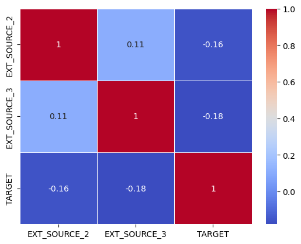

```python
sns.heatmap(data=round(app_flag_rmvd[['EXT_SOURCE_2','EXT_SOURCE_3','TARGET']].corr(),2),cmap='coolwarm',linewidths=.5,annot=True)
```

```python
app_score_col_rmvd = app_flag_rmvd.drop(['EXT_SOURCE_2','EXT_SOURCE_3'],axis=1)
app_score_col_rmvd.shape
```

```
(307511, 43)
```

They arent very much important according to col description i checked

# Feature Engineering

```python
app_score_col_rmvd.isnull().sum().sort_values()/app_score_col_rmvd.shape[0]
```

```
SK_ID_CURR                     0.000000
ORGANIZATION_TYPE              0.000000
LIVE_CITY_NOT_WORK_CITY        0.000000
REG_CITY_NOT_WORK_CITY         0.000000
REG_CITY_NOT_LIVE_CITY         0.000000
LIVE_REGION_NOT_WORK_REGION    0.000000
REG_REGION_NOT_WORK_REGION     0.000000
REG_REGION_NOT_LIVE_REGION     0.000000
HOUR_APPR_PROCESS_START        0.000000
WEEKDAY_APPR_PROCESS_START     0.000000
REGION_RATING_CLIENT_W_CITY    0.000000
DAYS_ID_PUBLISH                0.000000
DAYS_REGISTRATION              0.000000
DAYS_EMPLOYED                  0.000000
DAYS_BIRTH                     0.000000
REGION_RATING_CLIENT           0.000000
NAME_HOUSING_TYPE              0.000000
TARGET                         0.000000
NAME_CONTRACT_TYPE             0.000000
REGION_POPULATION_RELATIVE     0.000000
CNT_CHILDREN                   0.000000
AMT_INCOME_TOTAL               0.000000
AMT_CREDIT                     0.000000
CODE_GENDER                    0.000000
NAME_INCOME_TYPE               0.000000
NAME_EDUCATION_TYPE            0.000000
NAME_FAMILY_STATUS             0.000000
DAYS_LAST_PHONE_CHANGE         0.000003
CNT_FAM_MEMBERS                0.000007
AMT_ANNUITY                    0.000039
AMT_GOODS_PRICE                0.000904
DEF_60_CNT_SOCIAL_CIRCLE       0.003320
OBS_60_CNT_SOCIAL_CIRCLE       0.003320
DEF_30_CNT_SOCIAL_CIRCLE       0.003320
OBS_30_CNT_SOCIAL_CIRCLE       0.003320
NAME_TYPE_SUITE                0.004201
AMT_REQ_CREDIT_BUREAU_QRT      0.135016
AMT_REQ_CREDIT_BUREAU_HOUR     0.135016
AMT_REQ_CREDIT_BUREAU_DAY      0.135016
AMT_REQ_CREDIT_BUREAU_WEEK     0.135016
AMT_REQ_CREDIT_BUREAU_MON      0.135016
AMT_REQ_CREDIT_BUREAU_YEAR     0.135016
OCCUPATION_TYPE                0.313455
dtype: float64
```

### Missing imputation

CNT_FAM_MEMBERS

```python
app_score_col_rmvd.groupby('CNT_FAM_MEMBERS').size()
# most of the families have 2 members
```

```
CNT_FAM_MEMBERS
1.0      67847
2.0     158357
3.0      52601
4.0      24697
5.0       3478
6.0        408
7.0         81
8.0         20
9.0          6
10.0         3
11.0         1
12.0         2
13.0         1
14.0         2
15.0         1
16.0         2
20.0         2
dtype: int64
```

```python
app_score_col_rmvd['CNT_FAM_MEMBERS'].mode()
```

```
0    2.0
Name: CNT_FAM_MEMBERS, dtype: float64
```

```python
app_score_col_rmvd['CNT_FAM_MEMBERS'] = app_score_col_rmvd['CNT_FAM_MEMBERS'].fillna((app_score_col_rmvd['CNT_FAM_MEMBERS'].mode()[0]))
```

```python
app_score_col_rmvd['CNT_FAM_MEMBERS'].isnull().sum()
```

```
0
```

OCCUPATION_TYPE

```python
app_score_col_rmvd.groupby(['OCCUPATION_TYPE']).size().sort_values()
```

```
OCCUPATION_TYPE
IT staff                   526
HR staff                   563
Realty agents              751
Secretaries               1305
Waiters/barmen staff      1348
Low-skill Laborers        2093
Private service staff     2652
Cleaning staff            4653
Cooking staff             5946
Security staff            6721
Medicine staff            8537
Accountants               9813
High skill tech staff    11380
Drivers                  18603
Managers                 21371
Core staff               27570
Sales staff              32102
Laborers                 55186
dtype: int64
```

Laborers are the most so i decided to fill the missing with them

```python
app_score_col_rmvd['OCCUPATION_TYPE'].mode()[0]
```

```
'Laborers'
```

```python
app_score_col_rmvd['OCCUPATION_TYPE'] = app_score_col_rmvd['OCCUPATION_TYPE'].fillna((app_score_col_rmvd['OCCUPATION_TYPE'].mode()[0]))
```

```python
app_score_col_rmvd['OCCUPATION_TYPE'].isnull().sum()
```

```
0
```

So now we are done with replacing Family count and Ocupation type using mode

NAME_TYPE_SUITE

```python
app_score_col_rmvd['NAME_TYPE_SUITE'].isnull().sum()
```

```
1292
```

```python
app_score_col_rmvd['NAME_TYPE_SUITE'].mode()[0]
```

```
'Unaccompanied'
```

```python
app_score_col_rmvd.groupby(['NAME_TYPE_SUITE']).size()
```

```
NAME_TYPE_SUITE
Children             3267
Family              40149
Group of people       271
Other_A               866
Other_B              1770
Spouse, partner     11370
Unaccompanied      248526
dtype: int64
```

```python
app_score_col_rmvd['NAME_TYPE_SUITE'] = app_score_col_rmvd['NAME_TYPE_SUITE'].fillna((app_score_col_rmvd['NAME_TYPE_SUITE'].mode()[0]))
```

```python
app_score_col_rmvd['NAME_TYPE_SUITE'].isnull().sum()
```

```
0
```

AMT_ANNUITY

```python
app_score_col_rmvd['AMT_ANNUITY'].dtype
```

```
dtype('float64')
```

```python
# Its float type
app_score_col_rmvd['AMT_ANNUITY'].isnull().sum()
```

```
12
```

```python
app_score_col_rmvd['AMT_ANNUITY'].describe()
```

```
count    307499.000000
mean      27108.573909
std       14493.737315
min        1615.500000
25%       16524.000000
50%       24903.000000
75%       34596.000000
max      258025.500000
Name: AMT_ANNUITY, dtype: float64
```

it has minimum value 1615.500000 and maximum value 258025.500000 , median = 24903.000000 , mean = 27108.573909

mean and median are quitly close which indecates that data is not highly imbalanced, so we could use the mean here

```python
app_score_col_rmvd['AMT_ANNUITY'] = app_score_col_rmvd['AMT_ANNUITY'].fillna((app_score_col_rmvd['AMT_ANNUITY'].mean()))
```

```python
app_score_col_rmvd['AMT_ANNUITY'].isnull().sum()
```

```
0
```

here in these columns they are all related with the same missing value number:AMT_REQ_CREDIT_BUREAU_QRT 0.135016 AMT_REQ_CREDIT_BUREAU_HOUR 0.135016 AMT_REQ_CREDIT_BUREAU_DAY 0.135016 AMT_REQ_CREDIT_BUREAU_WEEK 0.135016 AMT_REQ_CREDIT_BUREAU_MON 0.135016 AMT_REQ_CREDIT_BUREAU_YEAR 0.135016

```python
app_score_col_rmvd['AMT_REQ_CREDIT_BUREAU_HOUR'].dtype
```

```
dtype('float64')
```

```python
app_score_col_rmvd['AMT_REQ_CREDIT_BUREAU_HOUR'].describe()
```

```
count    265992.000000
mean          0.006402
std           0.083849
min           0.000000
25%           0.000000
50%           0.000000
75%           0.000000
max           4.000000
Name: AMT_REQ_CREDIT_BUREAU_HOUR, dtype: float64
```

```python
app_score_col_rmvd['AMT_REQ_CREDIT_BUREAU_HOUR'].head()
```

```
0    0.0
1    0.0
2    0.0
3    NaN
4    0.0
Name: AMT_REQ_CREDIT_BUREAU_HOUR, dtype: float64
```

```python
app_score_col_rmvd['AMT_REQ_CREDIT_BUREAU_HOUR'].unique()
```

```
array([ 0., nan,  1.,  2.,  3.,  4.])
```

```python
amt_req_col = []

for col in app_score_col_rmvd.columns:
    if col.startswith("AMT_REQ_CREDIT_BUREAU"):
        amt_req_col.append(col)
amt_req_col


# here we put them all in a list as i said they are all the same so ill do it in one step rather than one by one
# and ill impute using median because median values 50% in the describe(skewed towards 0)
```

```
['AMT_REQ_CREDIT_BUREAU_HOUR',
 'AMT_REQ_CREDIT_BUREAU_DAY',
 'AMT_REQ_CREDIT_BUREAU_WEEK',
 'AMT_REQ_CREDIT_BUREAU_MON',
 'AMT_REQ_CREDIT_BUREAU_QRT',
 'AMT_REQ_CREDIT_BUREAU_YEAR']
```

```python
for col in amt_req_col:
    app_score_col_rmvd[col] = app_score_col_rmvd[col].fillna((app_score_col_rmvd[col].median()))
```

```python
app_score_col_rmvd[col].isnull().sum()
```

```
0
```

```python
app_score_col_rmvd.isnull().sum().sort_values()
```

```
SK_ID_CURR                        0
AMT_REQ_CREDIT_BUREAU_QRT         0
REGION_RATING_CLIENT_W_CITY       0
WEEKDAY_APPR_PROCESS_START        0
HOUR_APPR_PROCESS_START           0
REG_REGION_NOT_LIVE_REGION        0
REG_REGION_NOT_WORK_REGION        0
LIVE_REGION_NOT_WORK_REGION       0
REG_CITY_NOT_LIVE_CITY            0
REG_CITY_NOT_WORK_CITY            0
LIVE_CITY_NOT_WORK_CITY           0
ORGANIZATION_TYPE                 0
AMT_REQ_CREDIT_BUREAU_HOUR        0
AMT_REQ_CREDIT_BUREAU_DAY         0
AMT_REQ_CREDIT_BUREAU_WEEK        0
AMT_REQ_CREDIT_BUREAU_MON         0
CNT_FAM_MEMBERS                   0
OCCUPATION_TYPE                   0
REGION_RATING_CLIENT              0
DAYS_REGISTRATION                 0
TARGET                            0
NAME_CONTRACT_TYPE                0
CODE_GENDER                       0
CNT_CHILDREN                      0
AMT_INCOME_TOTAL                  0
DAYS_ID_PUBLISH                   0
AMT_ANNUITY                       0
AMT_CREDIT                        0
NAME_INCOME_TYPE                  0
NAME_EDUCATION_TYPE               0
NAME_FAMILY_STATUS                0
NAME_HOUSING_TYPE                 0
REGION_POPULATION_RELATIVE        0
DAYS_BIRTH                        0
DAYS_EMPLOYED                     0
NAME_TYPE_SUITE                   0
AMT_REQ_CREDIT_BUREAU_YEAR        0
DAYS_LAST_PHONE_CHANGE            1
AMT_GOODS_PRICE                 278
OBS_30_CNT_SOCIAL_CIRCLE       1021
DEF_30_CNT_SOCIAL_CIRCLE       1021
OBS_60_CNT_SOCIAL_CIRCLE       1021
DEF_60_CNT_SOCIAL_CIRCLE       1021
dtype: int64
```

```python
app_score_col_rmvd['AMT_GOODS_PRICE'].isnull().sum()
```

```
278
```

```python
app_score_col_rmvd['AMT_GOODS_PRICE'].describe()
```

```
count    3.072330e+05
mean     5.383962e+05
std      3.694465e+05
min      4.050000e+04
25%      2.385000e+05
50%      4.500000e+05
75%      6.795000e+05
max      4.050000e+06
Name: AMT_GOODS_PRICE, dtype: float64
```

```python
app_score_col_rmvd['AMT_GOODS_PRICE'].agg(['min','max','median'])
```

```
min         40500.0
max       4050000.0
median     450000.0
Name: AMT_GOODS_PRICE, dtype: float64
```

```python
app_score_col_rmvd['AMT_GOODS_PRICE'].mean()
```

```
538396.2074288895
```

```python
app_score_col_rmvd['AMT_GOODS_PRICE']=app_score_col_rmvd['AMT_GOODS_PRICE'].fillna(app_score_col_rmvd['AMT_GOODS_PRICE'].median())
```

median looks more relevent so we'll use median to fill missing values

```python
app_score_col_rmvd['AMT_GOODS_PRICE'].isnull().sum()
```

```
0
```

```python
app_score_col_rmvd.head()
```

|  | SK_ID_CURR | TARGET | NAME_CONTRACT_TYPE | CODE_GENDER | CNT_CHILDREN | AMT_INCOME_TOTAL | AMT_CREDIT | AMT_ANNUITY | AMT_GOODS_PRICE | NAME_TYPE_SUITE | NAME_INCOME_TYPE | NAME_EDUCATION_TYPE | NAME_FAMILY_STATUS | NAME_HOUSING_TYPE | REGION_POPULATION_RELATIVE | DAYS_BIRTH | DAYS_EMPLOYED | DAYS_REGISTRATION | DAYS_ID_PUBLISH | OCCUPATION_TYPE | CNT_FAM_MEMBERS | REGION_RATING_CLIENT | REGION_RATING_CLIENT_W_CITY | WEEKDAY_APPR_PROCESS_START | HOUR_APPR_PROCESS_START | REG_REGION_NOT_LIVE_REGION | REG_REGION_NOT_WORK_REGION | LIVE_REGION_NOT_WORK_REGION | REG_CITY_NOT_LIVE_CITY | … |
| --- | --- | --- | --- | --- | --- | --- | --- | --- | --- | --- | --- | --- | --- | --- | --- | --- | --- | --- | --- | --- | --- | --- | --- | --- | --- | --- | --- | --- | --- | --- |
| 0 | 100002 | 1 | Cash loans | M | 0 | 202500.0 | 406597.5 | 24700.5 | 351000.0 | Unaccompanied | Working | Secondary / secondary special | Single / not married | House / apartment | 0.018801 | -9461 | -637 | -3648.0 | -2120 | Laborers | 1.0 | 2 | 2 | WEDNESDAY | 10 | 0 | 0 | 0 | 0 | … |
| 1 | 100003 | 0 | Cash loans | F | 0 | 270000.0 | 1293502.5 | 35698.5 | 1129500.0 | Family | State servant | Higher education | Married | House / apartment | 0.003541 | -16765 | -1188 | -1186.0 | -291 | Core staff | 2.0 | 1 | 1 | MONDAY | 11 | 0 | 0 | 0 | 0 | … |
| 2 | 100004 | 0 | Revolving loans | M | 0 | 67500.0 | 135000.0 | 6750.0 | 135000.0 | Unaccompanied | Working | Secondary / secondary special | Single / not married | House / apartment | 0.010032 | -19046 | -225 | -4260.0 | -2531 | Laborers | 1.0 | 2 | 2 | MONDAY | 9 | 0 | 0 | 0 | 0 | … |
| 3 | 100006 | 0 | Cash loans | F | 0 | 135000.0 | 312682.5 | 29686.5 | 297000.0 | Unaccompanied | Working | Secondary / secondary special | Civil marriage | House / apartment | 0.008019 | -19005 | -3039 | -9833.0 | -2437 | Laborers | 2.0 | 2 | 2 | WEDNESDAY | 17 | 0 | 0 | 0 | 0 | … |
| 4 | 100007 | 0 | Cash loans | M | 0 | 121500.0 | 513000.0 | 21865.5 | 513000.0 | Unaccompanied | Working | Secondary / secondary special | Single / not married | House / apartment | 0.028663 | -19932 | -3038 | -4311.0 | -3458 | Core staff | 1.0 | 2 | 2 | THURSDAY | 11 | 0 | 0 | 0 | 0 | … |

```python
app_score_col_rmvd['AMT_CREDIT'].isnull().sum()
```

```
0
```

### Value Modification

Convert negative values

```python
days_col=[]

for col in app_score_col_rmvd.columns:
    if col.startswith("DAYS"):
        days_col.append(col)

days_col
```

```
['DAYS_BIRTH',
 'DAYS_EMPLOYED',
 'DAYS_REGISTRATION',
 'DAYS_ID_PUBLISH',
 'DAYS_LAST_PHONE_CHANGE']
```

```python
for col in days_col:
    app_score_col_rmvd[col]=abs(app_score_col_rmvd[col])
```

```python
app_score_col_rmvd.head()
```

|  | SK_ID_CURR | TARGET | NAME_CONTRACT_TYPE | CODE_GENDER | CNT_CHILDREN | AMT_INCOME_TOTAL | AMT_CREDIT | AMT_ANNUITY | AMT_GOODS_PRICE | NAME_TYPE_SUITE | NAME_INCOME_TYPE | NAME_EDUCATION_TYPE | NAME_FAMILY_STATUS | NAME_HOUSING_TYPE | REGION_POPULATION_RELATIVE | DAYS_BIRTH | DAYS_EMPLOYED | DAYS_REGISTRATION | DAYS_ID_PUBLISH | OCCUPATION_TYPE | CNT_FAM_MEMBERS | REGION_RATING_CLIENT | REGION_RATING_CLIENT_W_CITY | WEEKDAY_APPR_PROCESS_START | HOUR_APPR_PROCESS_START | REG_REGION_NOT_LIVE_REGION | REG_REGION_NOT_WORK_REGION | LIVE_REGION_NOT_WORK_REGION | REG_CITY_NOT_LIVE_CITY | … |
| --- | --- | --- | --- | --- | --- | --- | --- | --- | --- | --- | --- | --- | --- | --- | --- | --- | --- | --- | --- | --- | --- | --- | --- | --- | --- | --- | --- | --- | --- | --- |
| 0 | 100002 | 1 | Cash loans | M | 0 | 202500.0 | 406597.5 | 24700.5 | 351000.0 | Unaccompanied | Working | Secondary / secondary special | Single / not married | House / apartment | 0.018801 | 9461 | 637 | 3648.0 | 2120 | Laborers | 1.0 | 2 | 2 | WEDNESDAY | 10 | 0 | 0 | 0 | 0 | … |
| 1 | 100003 | 0 | Cash loans | F | 0 | 270000.0 | 1293502.5 | 35698.5 | 1129500.0 | Family | State servant | Higher education | Married | House / apartment | 0.003541 | 16765 | 1188 | 1186.0 | 291 | Core staff | 2.0 | 1 | 1 | MONDAY | 11 | 0 | 0 | 0 | 0 | … |
| 2 | 100004 | 0 | Revolving loans | M | 0 | 67500.0 | 135000.0 | 6750.0 | 135000.0 | Unaccompanied | Working | Secondary / secondary special | Single / not married | House / apartment | 0.010032 | 19046 | 225 | 4260.0 | 2531 | Laborers | 1.0 | 2 | 2 | MONDAY | 9 | 0 | 0 | 0 | 0 | … |
| 3 | 100006 | 0 | Cash loans | F | 0 | 135000.0 | 312682.5 | 29686.5 | 297000.0 | Unaccompanied | Working | Secondary / secondary special | Civil marriage | House / apartment | 0.008019 | 19005 | 3039 | 9833.0 | 2437 | Laborers | 2.0 | 2 | 2 | WEDNESDAY | 17 | 0 | 0 | 0 | 0 | … |
| 4 | 100007 | 0 | Cash loans | M | 0 | 121500.0 | 513000.0 | 21865.5 | 513000.0 | Unaccompanied | Working | Secondary / secondary special | Single / not married | House / apartment | 0.028663 | 19932 | 3038 | 4311.0 | 3458 | Core staff | 1.0 | 2 | 2 | THURSDAY | 11 | 0 | 0 | 0 | 0 | … |

```python
len(app_score_col_rmvd.columns)
```

```
43
```

```python
app_score_col_rmvd.info()
```

```
<class 'pandas.core.frame.DataFrame'>
RangeIndex: 307511 entries, 0 to 307510
Data columns (total 43 columns):
 #   Column                       Non-Null Count   Dtype
---  ------                       --------------   -----
 0   SK_ID_CURR                   307511 non-null  int64
 1   TARGET                       307511 non-null  int64
 2   NAME_CONTRACT_TYPE           307511 non-null  object
 3   CODE_GENDER                  307511 non-null  object
 4   CNT_CHILDREN                 307511 non-null  int64
 5   AMT_INCOME_TOTAL             307511 non-null  float64
 6   AMT_CREDIT                   307511 non-null  float64
 7   AMT_ANNUITY                  307511 non-null  float64
 8   AMT_GOODS_PRICE              307511 non-null  float64
 9   NAME_TYPE_SUITE              307511 non-null  object
```

[output cut: 35 more lines]

1. object : character variable
2. float: continous variable

```python
app_score_col_rmvd.nunique().sort_values()
```

```
LIVE_REGION_NOT_WORK_REGION         2
TARGET                              2
NAME_CONTRACT_TYPE                  2
REG_REGION_NOT_LIVE_REGION          2
REG_CITY_NOT_LIVE_CITY              2
REG_CITY_NOT_WORK_CITY              2
LIVE_CITY_NOT_WORK_CITY             2
REG_REGION_NOT_WORK_REGION          2
REGION_RATING_CLIENT_W_CITY         3
REGION_RATING_CLIENT                3
CODE_GENDER                         3
NAME_EDUCATION_TYPE                 5
AMT_REQ_CREDIT_BUREAU_HOUR          5
NAME_HOUSING_TYPE                   6
NAME_FAMILY_STATUS                  6
WEEKDAY_APPR_PROCESS_START          7
NAME_TYPE_SUITE                     7
NAME_INCOME_TYPE                    8
AMT_REQ_CREDIT_BUREAU_DAY           9
DEF_60_CNT_SOCIAL_CIRCLE            9
AMT_REQ_CREDIT_BUREAU_WEEK          9
DEF_30_CNT_SOCIAL_CIRCLE           10
AMT_REQ_CREDIT_BUREAU_QRT          11
CNT_CHILDREN                       15
CNT_FAM_MEMBERS                    17
OCCUPATION_TYPE                    18
HOUR_APPR_PROCESS_START            24
AMT_REQ_CREDIT_BUREAU_MON          24
AMT_REQ_CREDIT_BUREAU_YEAR         25
OBS_30_CNT_SOCIAL_CIRCLE           33
OBS_60_CNT_SOCIAL_CIRCLE           33
ORGANIZATION_TYPE                  58
REGION_POPULATION_RELATIVE         81
AMT_GOODS_PRICE                  1002
AMT_INCOME_TOTAL                 2548
DAYS_LAST_PHONE_CHANGE           3773
AMT_CREDIT                       5603
DAYS_ID_PUBLISH                  6168
DAYS_EMPLOYED                   12574
AMT_ANNUITY                     13673
DAYS_REGISTRATION               15688
DAYS_BIRTH                      17460
SK_ID_CURR                     307511
dtype: int64
```

### Outlier detection and treatment

```python
app_score_col_rmvd['AMT_GOODS_PRICE'].describe()
```

```
count    3.075110e+05
mean     5.383163e+05
std      3.692890e+05
min      4.050000e+04
25%      2.385000e+05
50%      4.500000e+05
75%      6.795000e+05
max      4.050000e+06
Name: AMT_GOODS_PRICE, dtype: float64
```

```python
app_score_col_rmvd['AMT_GOODS_PRICE'].agg(['min','max','median'])
```

```
min         40500.0
max       4050000.0
median     450000.0
Name: AMT_GOODS_PRICE, dtype: float64
```

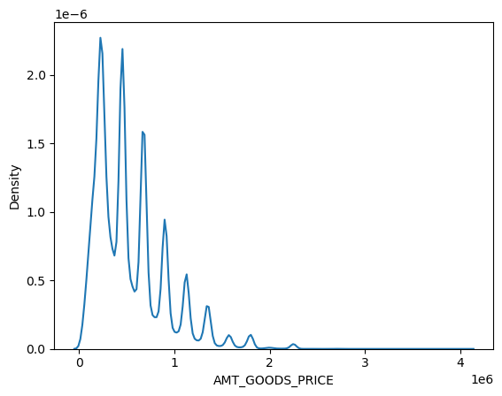

```python
sns.kdeplot(data=app_score_col_rmvd,x='AMT_GOODS_PRICE')
```

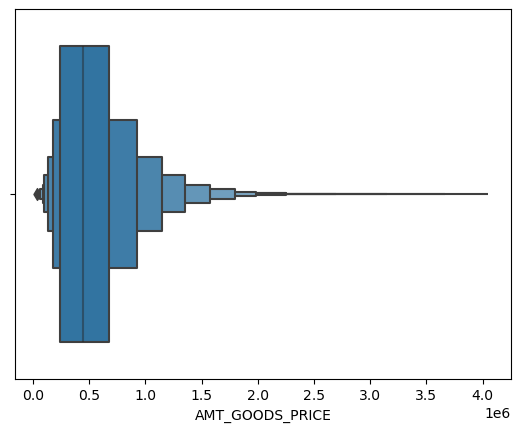

```python
sns.boxenplot(data=app_score_col_rmvd,x='AMT_GOODS_PRICE')
```

```python
app_score_col_rmvd['AMT_GOODS_PRICE'].quantile([0.1,0.2,0.3,0.4,0.5,0.6,0.7,0.8,0.9,0.99])
```

```
0.10     180000.0
0.20     225000.0
0.30     270000.0
0.40     378000.0
0.50     450000.0
0.60     522000.0
0.70     675000.0
0.80     814500.0
0.90    1093500.0
0.99    1800000.0
Name: AMT_GOODS_PRICE, dtype: float64
```

0.9 has huge variance

### Binning

Variables ill do binning on:

1. AMT_GOODS_PRICE
2. AMT_INCOME_TOTAL
3. AMT_CREDIT
4. AMT_ANNUITY
5. DAYS_EMPLOYED
6. DAYS_BIRTH

Binning is grouping values together for example (for continous values) </br>age:

1. 20 (20-30)
2. 25 (20-30)
3. 34 (30-50)
4. 76 (50-80)

the most of values bellow 1 million, so this will help us in binning

```python
# 50k as min value is 4.5k
bins=[0,100000,200000,300000,400000,500000,600000,700000,
      800000,900000,4050000]

ranges=['0-100K','100K-200K','200K-300K','300K-400K','400K-500K',
        '500K-600K','600K-700K','700K-800K','800K-900K','Above 900K']

app_score_col_rmvd['AMT_GOODS_PRICE_RANGE']=pd.cut(app_score_col_rmvd['AMT_GOODS_PRICE'],bins,labels=ranges)
```

```python
app_score_col_rmvd.groupby(['AMT_GOODS_PRICE_RANGE']).size()
```

```
AMT_GOODS_PRICE_RANGE
0-100K         8709
100K-200K     32956
200K-300K     62761
300K-400K     21219
400K-500K     57251
500K-600K     13117
600K-700K     40024
700K-800K      8110
800K-900K     21484
Above 900K    41880
dtype: int64
```

```python
app_score_col_rmvd['AMT_INCOME_TOTAL'].quantile([0.1,0.2,0.3,0.4,0.5,0.6,0.7,0.8,0.9,0.99])
```

```
0.10     81000.0
0.20     99000.0
0.30    112500.0
0.40    135000.0
0.50    147150.0
0.60    162000.0
0.70    180000.0
0.80    225000.0
0.90    270000.0
0.99    472500.0
Name: AMT_INCOME_TOTAL, dtype: float64
```

```python
app_score_col_rmvd['AMT_INCOME_TOTAL'].max()
```

```
117000000.0
```

```python
bins=[0,100000,150000,200000,250000,300000,350000,400000,117000000]

ranges=['0-100K','100K-150K','150K-200K','200K-250K','250K-300K',
        '300K-350K','350K-400K','Above 400K']

app_score_col_rmvd['AMT_INCOME_TOTAL_RANGE']=pd.cut(app_score_col_rmvd['AMT_INCOME_TOTAL'],bins,labels=ranges)
```

```python
app_score_col_rmvd.groupby(['AMT_INCOME_TOTAL_RANGE']).size()
```

```
AMT_INCOME_TOTAL_RANGE
0-100K        63698
100K-150K     91591
150K-200K     64307
200K-250K     48137
250K-300K     17039
300K-350K      8874
350K-400K      5802
Above 400K     8063
dtype: int64
```

```python
app_score_col_rmvd['AMT_INCOME_TOTAL_RANGE'].isnull().sum()
```

```
0
```

```python
app_score_col_rmvd['AMT_CREDIT'].quantile([0.1,0.2,0.3,0.4,0.5,0.6,0.7,0.8,0.9,0.99])
```

```
0.10     180000.0
0.20     254700.0
0.30     306306.0
0.40     432000.0
0.50     513531.0
0.60     604152.0
0.70     755190.0
0.80     900000.0
0.90    1133748.0
0.99    1854000.0
Name: AMT_CREDIT, dtype: float64
```

```python
app_score_col_rmvd['AMT_CREDIT'].max()
```

```
4050000.0
```

```python
bins=[0,200000,400000,600000,800000,900000,1000000,4050000]

ranges=['0-200K','200K-400K','400K-600K','600K-800K','800K-900K',
        '900K-1M','Above 1M']

app_score_col_rmvd['AMT_CREDIT_RANGE']=pd.cut(app_score_col_rmvd['AMT_CREDIT'],bins,labels=ranges)
```

```python
app_score_col_rmvd['AMT_CREDIT'].isnull().sum()
```

```
0
```

```python
app_score_col_rmvd.groupby(['AMT_CREDIT_RANGE']).size()
```

```
AMT_CREDIT_RANGE
0-200K       36144
200K-400K    81151
400K-600K    66270
600K-800K    43242
800K-900K    21792
900K-1M       8927
Above 1M     49985
dtype: int64
```

```python
app_score_col_rmvd['AMT_ANNUITY'].quantile([0.1,0.2,0.3,0.4,0.5,0.6,0.7,0.8,0.9,0.99])
```

```
0.10    11074.5
0.20    14701.5
0.30    18189.0
0.40    21870.0
0.50    24903.0
0.60    28062.0
0.70    32004.0
0.80    37516.5
0.90    45954.0
0.99    70006.5
Name: AMT_ANNUITY, dtype: float64
```

```python
app_score_col_rmvd['AMT_ANNUITY'].max()
```

```
258025.5
```

```python
bins=[0,25000,50000,100000,150000,200000,258025.5]

ranges=['0-25K','25K-50K','50K-100K','100K-150K','150K-200K',
        'Above 200K']

app_score_col_rmvd['AMT_ANNUITY_RANGE']=pd.cut(app_score_col_rmvd['AMT_ANNUITY'],bins,labels=ranges)
```

```python
app_score_col_rmvd['AMT_ANNUITY'].isnull().sum()
```

```
0
```

```python
app_score_col_rmvd.groupby(['AMT_ANNUITY_RANGE']).size()
```

```
AMT_ANNUITY_RANGE
0-25K         154867
25K-50K       131347
50K-100K       20792
100K-150K        437
150K-200K         32
Above 200K        36
dtype: int64
```

```python
app_score_col_rmvd['DAYS_EMPLOYED'].agg(['min','max','median'])
```

```
min            0.0
max       365243.0
median      2219.0
Name: DAYS_EMPLOYED, dtype: float64
```

```python
app_score_col_rmvd['DAYS_EMPLOYED'].quantile([0.1,0.2,0.3,0.4,0.5,0.6,0.7,0.8,0.9,0.99])
```

```
0.10       392.0
0.20       749.0
0.30      1132.0
0.40      1597.0
0.50      2219.0
0.60      3032.0
0.70      4435.0
0.80      9188.0
0.90    365243.0
0.99    365243.0
Name: DAYS_EMPLOYED, dtype: float64
```

```python
app_score_col_rmvd[app_score_col_rmvd['DAYS_EMPLOYED']<app_score_col_rmvd['DAYS_EMPLOYED'].max()].max()['DAYS_EMPLOYED']
```

```
17912
```

```python
app_score_col_rmvd['DAYS_EMPLOYED'].max()
```

```
365243
```

bins = on excel

1. 0 - 0*365 = 0
2. 5 - 5*365 = 1825
3. 10 - 10*365 = 3650
4. 15 = 5475
5. 20
6. 25
7. 30
8. 35

.......

50

```python
bins=[0,1825,3650,5475,7300,9125,10950,12775,14600,16425,18250,365243]

ranges=['0-5Y','5Y-10Y','10Y-15Y','15Y-20Y','20Y-25Y','25Y-30Y','30Y-35Y','35Y-40Y','40Y-45Y','45Y-50Y',
        'Above 50Y']

app_score_col_rmvd['DAYS_EMPLOYED_RANGE']=pd.cut(app_score_col_rmvd['DAYS_EMPLOYED'],bins,labels=ranges)
```

```python
app_score_col_rmvd.groupby(['DAYS_EMPLOYED_RANGE']).size()
```

```
DAYS_EMPLOYED_RANGE
0-5Y         136309
5Y-10Y        64872
10Y-15Y       27549
15Y-20Y       10849
20Y-25Y        6243
25Y-30Y        3308
30Y-35Y        1939
35Y-40Y         832
40Y-45Y         210
45Y-50Y          24
Above 50Y     55374
dtype: int64
```

```python
app_score_col_rmvd['DAYS_EMPLOYED_RANGE'].isnull().sum()
```

```
2
```

```python
app_score_col_rmvd['DAYS_BIRTH'].min()
```

```
7489
```

```python
app_score_col_rmvd['DAYS_BIRTH'].agg(['min','max','median'])
```

```
min        7489.0
max       25229.0
median    15750.0
Name: DAYS_BIRTH, dtype: float64
```

```python
app_score_col_rmvd['DAYS_BIRTH'].quantile([0.1,0.2,0.3,0.4,0.5,0.6,0.7,0.8,0.9,0.99])
```

```
0.10    10284.0
0.20    11694.0
0.30    13140.0
0.40    14416.0
0.50    15750.0
0.60    17220.0
0.70    18885.0
0.80    20474.0
0.90    22181.0
0.99    24419.0
Name: DAYS_BIRTH, dtype: float64
```

```python
app_score_col_rmvd['DAYS_BIRTH'].max()
```

```
25229
```

```python
bins=[0,7300,10950,14600,18250,21900,25229]

ranges=['20Y','20Y-30Y','30Y-40Y','40Y-50Y','50Y-60Y',
        'Above 60Y']

app_score_col_rmvd['DAYS_BIRTH_RANGE']=pd.cut(app_score_col_rmvd['DAYS_BIRTH'],bins,labels=ranges)
```

```python
app_score_col_rmvd.groupby(['DAYS_BIRTH_RANGE']).size()
```

```
DAYS_BIRTH_RANGE
20Y              0
20Y-30Y      45021
30Y-40Y      82308
40Y-50Y      76541
50Y-60Y      68062
Above 60Y    35579
dtype: int64
```

```python
app_score_col_rmvd['DAYS_BIRTH_RANGE'].isnull().sum()
```

```
0
```

# Data Analysis

```python
app_score_col_rmvd.info()
```

```
<class 'pandas.core.frame.DataFrame'>
RangeIndex: 307511 entries, 0 to 307510
Data columns (total 49 columns):
 #   Column                       Non-Null Count   Dtype
---  ------                       --------------   -----
 0   SK_ID_CURR                   307511 non-null  int64
 1   TARGET                       307511 non-null  int64
 2   NAME_CONTRACT_TYPE           307511 non-null  object
 3   CODE_GENDER                  307511 non-null  object
 4   CNT_CHILDREN                 307511 non-null  int64
 5   AMT_INCOME_TOTAL             307511 non-null  float64
 6   AMT_CREDIT                   307511 non-null  float64
 7   AMT_ANNUITY                  307511 non-null  float64
 8   AMT_GOODS_PRICE              307511 non-null  float64
 9   NAME_TYPE_SUITE              307511 non-null  object
```

[output cut: 41 more lines]

49 columns

float(continous variable) , object(categorical variable) , category(ive created them )

```python
app_score_col_rmvd.dtypes.value_counts()
```

```
float64     18
int64       15
object      10
category     1
category     1
category     1
category     1
category     1
category     1
Name: count, dtype: int64
```

16 character variable

33 numerical variable

I'LL focus now on object variables

```python
app_score_col_rmvd.select_dtypes(include=['object']).head()
```

|  | NAME_CONTRACT_TYPE | CODE_GENDER | NAME_TYPE_SUITE | NAME_INCOME_TYPE | NAME_EDUCATION_TYPE | NAME_FAMILY_STATUS | NAME_HOUSING_TYPE | OCCUPATION_TYPE | WEEKDAY_APPR_PROCESS_START | ORGANIZATION_TYPE |
| --- | --- | --- | --- | --- | --- | --- | --- | --- | --- | --- |
| 0 | Cash loans | M | Unaccompanied | Working | Secondary / secondary special | Single / not married | House / apartment | Laborers | WEDNESDAY | Business Entity Type 3 |
| 1 | Cash loans | F | Family | State servant | Higher education | Married | House / apartment | Core staff | MONDAY | School |
| 2 | Revolving loans | M | Unaccompanied | Working | Secondary / secondary special | Single / not married | House / apartment | Laborers | MONDAY | Government |
| 3 | Cash loans | F | Unaccompanied | Working | Secondary / secondary special | Civil marriage | House / apartment | Laborers | WEDNESDAY | Business Entity Type 3 |
| 4 | Cash loans | M | Unaccompanied | Working | Secondary / secondary special | Single / not married | House / apartment | Core staff | THURSDAY | Religion |

```python
obj_var = app_score_col_rmvd.select_dtypes(include=['object']).columns
obj_var
```

```
Index(['NAME_CONTRACT_TYPE', 'CODE_GENDER', 'NAME_TYPE_SUITE',
       'NAME_INCOME_TYPE', 'NAME_EDUCATION_TYPE', 'NAME_FAMILY_STATUS',
       'NAME_HOUSING_TYPE', 'OCCUPATION_TYPE', 'WEEKDAY_APPR_PROCESS_START',
       'ORGANIZATION_TYPE'],
      dtype='object')
```

```python
app_score_col_rmvd.groupby(['NAME_CONTRACT_TYPE']).size()
```

```
NAME_CONTRACT_TYPE
Cash loans         278232
Revolving loans     29279
dtype: int64
```

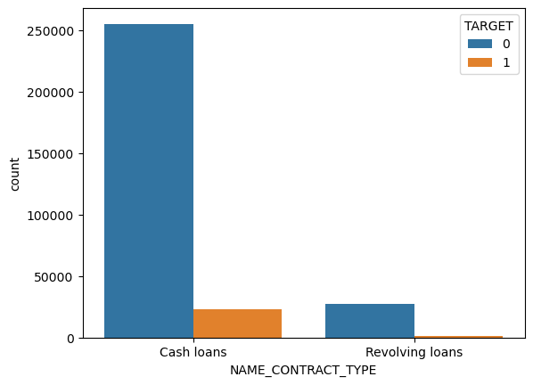

```python
# LETS SEE PROPORTION OF THIS VALUE
sns.countplot(data=app_score_col_rmvd,x='NAME_CONTRACT_TYPE',hue='TARGET')
```

RESULTS: there are 2 types of loans given to the customer (cash loan , revolving loan) in cash loan approx >250 are non defaulters and rest defaulted

```python
#  Check percentage
data_pct = app_score_col_rmvd[['NAME_CONTRACT_TYPE','TARGET']].groupby(['NAME_CONTRACT_TYPE'],as_index=False).mean()

# as_index= False because target was written higher thn the other column to just make it look proper
```

```python
data_pct['PCT']=data_pct['TARGET']*100
```

```python
data_pct
```

|  | NAME_CONTRACT_TYPE | TARGET | PCT |
| --- | --- | --- | --- |
| 0 | Cash loans | 0.083459 | 8.345913 |
| 1 | Revolving loans | 0.054783 | 5.478329 |

i found defaulters by loan type

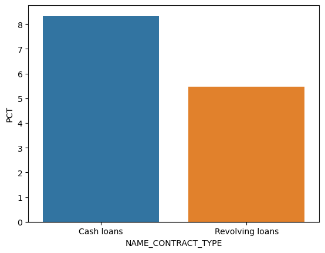

```python
sns.barplot(data=data_pct,x='NAME_CONTRACT_TYPE',y='PCT')
```

8% OF CUSTOMER ARE DEFAULTED

5.5% OF CUSTOMERS TAKEN REVOLVING LOAN OUT HAVE DEFAULTED

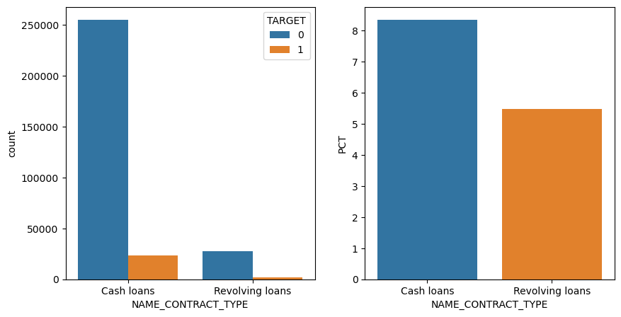

```python
plt.figure(figsize=(10,5))

plt.subplot(1,2,1)
sns.countplot(data=app_score_col_rmvd,x='NAME_CONTRACT_TYPE',hue='TARGET')


plt.subplot(1,2,2)
sns.barplot(data=data_pct,x='NAME_CONTRACT_TYPE',y='PCT')
```

```python
len(obj_var)
```

```
10
```

```python
obj_var
```

```
Index(['NAME_CONTRACT_TYPE', 'CODE_GENDER', 'NAME_TYPE_SUITE',
       'NAME_INCOME_TYPE', 'NAME_EDUCATION_TYPE', 'NAME_FAMILY_STATUS',
       'NAME_HOUSING_TYPE', 'OCCUPATION_TYPE', 'WEEKDAY_APPR_PROCESS_START',
       'ORGANIZATION_TYPE'],
      dtype='object')
```

##### Here i want to do the same i did for name contract type on all object variables in one step

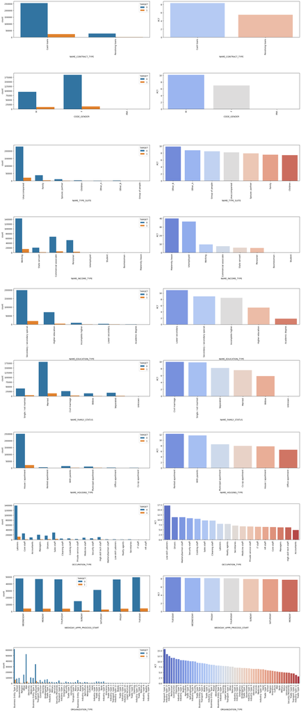

```python
plt.figure(figsize=(25,60))

# as if im going to use 2 variables obj_var[:2]

for i, var in enumerate(obj_var):

    data_pct = app_score_col_rmvd[[var,'TARGET']].groupby([var],as_index=False).mean().sort_values(by='TARGET',ascending=False)

    data_pct['PCT']=data_pct['TARGET']*100

    plt.subplot(10,2,i+i+1)
#     i=0 0+0+1=1
# 10 rows ,2 columns
    plt.subplots_adjust(wspace=0.1,hspace=1)
    sns.countplot(data=app_score_col_rmvd,x=var,hue='TARGET')
    plt.xticks(rotation=90)

    plt.subplot(10,2,i+i+2)
    sns.barplot(data=data_pct , x=var , y='PCT', palette='coolwarm')
    plt.xticks(rotation=90)
```

```python
app_score_col_rmvd['NAME_EDUCATION_TYPE'].unique()
```

```
array(['Secondary / secondary special', 'Higher education',
       'Incomplete higher', 'Lower secondary', 'Academic degree'],
      dtype=object)
```

### Analysis (Univariate analysis for all the categorical variables ):

1. Name Contract : most of the customers took cash loans
2. Code Gender:mostly females have taken loans and they are less likely to default , so we could say that females are safer persons to target for giving loans / female default rate is below 8% or lower than male , most of loans are taken by females
3. Name Type Suite: most of the customers were unaccompanied while taking loans /Unaccompained people have taken most of loans and default rate is approx 8.5% which is still ok safe
4. Name Income Type: the safest segment is working , commercial assosiates and pansioners and there default rate is also low
5. Name Education Type: higher education is the safest segment to give the loan with a default rate less than 5%
6. Name Family Status: married people are the safest segment to give loans/target with default rate less than 8%
7. Name Housing Type: house appartment segment are the safest to target with default rate approx 8&
8. Occupation Type: Low Skill Labourors & Drivers has the highest defaulters , Accountants are less defaulters , Labourors and Core Staff are safer to target with a default rate >=7.5 to 10%
9. Organization Type: Transport type 3 highest defaulter , Others & Buisness Entuty Type 3 & Self Employed are good to go with default rate around 10%

```python
app_score_col_rmvd.dtypes
```

```
SK_ID_CURR                        int64
TARGET                            int64
NAME_CONTRACT_TYPE               object
CODE_GENDER                      object
CNT_CHILDREN                      int64
AMT_INCOME_TOTAL                float64
AMT_CREDIT                      float64
AMT_ANNUITY                     float64
AMT_GOODS_PRICE                 float64
NAME_TYPE_SUITE                  object
NAME_INCOME_TYPE                 object
NAME_EDUCATION_TYPE              object
NAME_FAMILY_STATUS               object
NAME_HOUSING_TYPE                object
REGION_POPULATION_RELATIVE      float64
DAYS_BIRTH                        int64
DAYS_EMPLOYED                     int64
DAYS_REGISTRATION               float64
DAYS_ID_PUBLISH                   int64
OCCUPATION_TYPE                  object
CNT_FAM_MEMBERS                 float64
REGION_RATING_CLIENT              int64
REGION_RATING_CLIENT_W_CITY       int64
WEEKDAY_APPR_PROCESS_START       object
HOUR_APPR_PROCESS_START           int64
REG_REGION_NOT_LIVE_REGION        int64
REG_REGION_NOT_WORK_REGION        int64
LIVE_REGION_NOT_WORK_REGION       int64
REG_CITY_NOT_LIVE_CITY            int64
REG_CITY_NOT_WORK_CITY            int64
LIVE_CITY_NOT_WORK_CITY           int64
ORGANIZATION_TYPE                object
OBS_30_CNT_SOCIAL_CIRCLE        float64
DEF_30_CNT_SOCIAL_CIRCLE        float64
OBS_60_CNT_SOCIAL_CIRCLE        float64
DEF_60_CNT_SOCIAL_CIRCLE        float64
DAYS_LAST_PHONE_CHANGE          float64
AMT_REQ_CREDIT_BUREAU_HOUR      float64
AMT_REQ_CREDIT_BUREAU_DAY       float64
AMT_REQ_CREDIT_BUREAU_WEEK      float64
AMT_REQ_CREDIT_BUREAU_MON       float64
AMT_REQ_CREDIT_BUREAU_QRT       float64
AMT_REQ_CREDIT_BUREAU_YEAR      float64
AMT_GOODS_PRICE_RANGE          category
AMT_INCOME_TOTAL_RANGE         category
AMT_CREDIT_RANGE               category
AMT_ANNUITY_RANGE              category
DAYS_EMPLOYED_RANGE            category
DAYS_BIRTH_RANGE               category
dtype: object
```

```python
app_score_col_rmvd.dtypes.value_counts()
```

```
float64     18
int64       15
object      10
category     1
category     1
category     1
category     1
category     1
category     1
Name: count, dtype: int64
```

```python
num_var = app_score_col_rmvd.select_dtypes(include=['float64','int64']).columns
num_cat_var = app_score_col_rmvd.select_dtypes(include=['float64','int64','category']).columns
```

```python
len(num_var)
```

```
33
```

```python
app_score_col_rmvd[num_var].head()
```

|  | SK_ID_CURR | TARGET | CNT_CHILDREN | AMT_INCOME_TOTAL | AMT_CREDIT | AMT_ANNUITY | AMT_GOODS_PRICE | REGION_POPULATION_RELATIVE | DAYS_BIRTH | DAYS_EMPLOYED | DAYS_REGISTRATION | DAYS_ID_PUBLISH | CNT_FAM_MEMBERS | REGION_RATING_CLIENT | REGION_RATING_CLIENT_W_CITY | HOUR_APPR_PROCESS_START | REG_REGION_NOT_LIVE_REGION | REG_REGION_NOT_WORK_REGION | LIVE_REGION_NOT_WORK_REGION | REG_CITY_NOT_LIVE_CITY | REG_CITY_NOT_WORK_CITY | LIVE_CITY_NOT_WORK_CITY | OBS_30_CNT_SOCIAL_CIRCLE | DEF_30_CNT_SOCIAL_CIRCLE | OBS_60_CNT_SOCIAL_CIRCLE | DEF_60_CNT_SOCIAL_CIRCLE | DAYS_LAST_PHONE_CHANGE | AMT_REQ_CREDIT_BUREAU_HOUR | AMT_REQ_CREDIT_BUREAU_DAY | … |
| --- | --- | --- | --- | --- | --- | --- | --- | --- | --- | --- | --- | --- | --- | --- | --- | --- | --- | --- | --- | --- | --- | --- | --- | --- | --- | --- | --- | --- | --- | --- |
| 0 | 100002 | 1 | 0 | 202500.0 | 406597.5 | 24700.5 | 351000.0 | 0.018801 | 9461 | 637 | 3648.0 | 2120 | 1.0 | 2 | 2 | 10 | 0 | 0 | 0 | 0 | 0 | 0 | 2.0 | 2.0 | 2.0 | 2.0 | 1134.0 | 0.0 | 0.0 | … |
| 1 | 100003 | 0 | 0 | 270000.0 | 1293502.5 | 35698.5 | 1129500.0 | 0.003541 | 16765 | 1188 | 1186.0 | 291 | 2.0 | 1 | 1 | 11 | 0 | 0 | 0 | 0 | 0 | 0 | 1.0 | 0.0 | 1.0 | 0.0 | 828.0 | 0.0 | 0.0 | … |
| 2 | 100004 | 0 | 0 | 67500.0 | 135000.0 | 6750.0 | 135000.0 | 0.010032 | 19046 | 225 | 4260.0 | 2531 | 1.0 | 2 | 2 | 9 | 0 | 0 | 0 | 0 | 0 | 0 | 0.0 | 0.0 | 0.0 | 0.0 | 815.0 | 0.0 | 0.0 | … |
| 3 | 100006 | 0 | 0 | 135000.0 | 312682.5 | 29686.5 | 297000.0 | 0.008019 | 19005 | 3039 | 9833.0 | 2437 | 2.0 | 2 | 2 | 17 | 0 | 0 | 0 | 0 | 0 | 0 | 2.0 | 0.0 | 2.0 | 0.0 | 617.0 | 0.0 | 0.0 | … |
| 4 | 100007 | 0 | 0 | 121500.0 | 513000.0 | 21865.5 | 513000.0 | 0.028663 | 19932 | 3038 | 4311.0 | 3458 | 1.0 | 2 | 2 | 11 | 0 | 0 | 0 | 0 | 1 | 1 | 0.0 | 0.0 | 0.0 | 0.0 | 1106.0 | 0.0 | 0.0 | … |

```python
num_data=app_score_col_rmvd[num_var]
num_data.groupby(['TARGET']).size()

# this data is imbalanced , number of defaulter is lowwww
```

```
TARGET
0    282686
1     24825
dtype: int64
```

```python
num_data.groupby(['TARGET']).size()/num_data.shape[0]*100
```

```
TARGET
0    91.927118
1     8.072882
dtype: float64
```

```python
defaulters=num_data[num_data['TARGET']==1].drop(['TARGET'],axis=1)
defaulters.head()
```

|  | SK_ID_CURR | CNT_CHILDREN | AMT_INCOME_TOTAL | AMT_CREDIT | AMT_ANNUITY | AMT_GOODS_PRICE | REGION_POPULATION_RELATIVE | DAYS_BIRTH | DAYS_EMPLOYED | DAYS_REGISTRATION | DAYS_ID_PUBLISH | CNT_FAM_MEMBERS | REGION_RATING_CLIENT | REGION_RATING_CLIENT_W_CITY | HOUR_APPR_PROCESS_START | REG_REGION_NOT_LIVE_REGION | REG_REGION_NOT_WORK_REGION | LIVE_REGION_NOT_WORK_REGION | REG_CITY_NOT_LIVE_CITY | REG_CITY_NOT_WORK_CITY | LIVE_CITY_NOT_WORK_CITY | OBS_30_CNT_SOCIAL_CIRCLE | DEF_30_CNT_SOCIAL_CIRCLE | OBS_60_CNT_SOCIAL_CIRCLE | DEF_60_CNT_SOCIAL_CIRCLE | DAYS_LAST_PHONE_CHANGE | AMT_REQ_CREDIT_BUREAU_HOUR | AMT_REQ_CREDIT_BUREAU_DAY | AMT_REQ_CREDIT_BUREAU_WEEK | … |
| --- | --- | --- | --- | --- | --- | --- | --- | --- | --- | --- | --- | --- | --- | --- | --- | --- | --- | --- | --- | --- | --- | --- | --- | --- | --- | --- | --- | --- | --- | --- |
| 0 | 100002 | 0 | 202500.0 | 406597.5 | 24700.5 | 351000.0 | 0.018801 | 9461 | 637 | 3648.0 | 2120 | 1.0 | 2 | 2 | 10 | 0 | 0 | 0 | 0 | 0 | 0 | 2.0 | 2.0 | 2.0 | 2.0 | 1134.0 | 0.0 | 0.0 | 0.0 | … |
| 26 | 100031 | 0 | 112500.0 | 979992.0 | 27076.5 | 702000.0 | 0.018029 | 18724 | 2628 | 6573.0 | 1827 | 1.0 | 3 | 2 | 9 | 0 | 0 | 0 | 0 | 0 | 0 | 10.0 | 1.0 | 10.0 | 0.0 | 161.0 | 0.0 | 0.0 | 0.0 | … |
| 40 | 100047 | 0 | 202500.0 | 1193580.0 | 35028.0 | 855000.0 | 0.025164 | 17482 | 1262 | 1182.0 | 1029 | 2.0 | 2 | 2 | 9 | 0 | 0 | 0 | 0 | 0 | 0 | 0.0 | 0.0 | 0.0 | 0.0 | 1075.0 | 0.0 | 0.0 | 0.0 | … |
| 42 | 100049 | 0 | 135000.0 | 288873.0 | 16258.5 | 238500.0 | 0.007305 | 13384 | 3597 | 45.0 | 4409 | 2.0 | 3 | 3 | 11 | 0 | 0 | 0 | 0 | 0 | 0 | 1.0 | 0.0 | 1.0 | 0.0 | 1480.0 | 0.0 | 0.0 | 0.0 | … |
| 81 | 100096 | 0 | 81000.0 | 252000.0 | 14593.5 | 252000.0 | 0.028663 | 24794 | 365243 | 5391.0 | 4199 | 2.0 | 2 | 2 | 10 | 0 | 0 | 0 | 0 | 0 | 0 | 1.0 | 1.0 | 1.0 | 1.0 | 0.0 | 0.0 | 0.0 | 0.0 | … |

```python
repayers=num_data[num_data['TARGET']==0].drop(['TARGET'],axis=1)
repayers.head()
```

|  | SK_ID_CURR | CNT_CHILDREN | AMT_INCOME_TOTAL | AMT_CREDIT | AMT_ANNUITY | AMT_GOODS_PRICE | REGION_POPULATION_RELATIVE | DAYS_BIRTH | DAYS_EMPLOYED | DAYS_REGISTRATION | DAYS_ID_PUBLISH | CNT_FAM_MEMBERS | REGION_RATING_CLIENT | REGION_RATING_CLIENT_W_CITY | HOUR_APPR_PROCESS_START | REG_REGION_NOT_LIVE_REGION | REG_REGION_NOT_WORK_REGION | LIVE_REGION_NOT_WORK_REGION | REG_CITY_NOT_LIVE_CITY | REG_CITY_NOT_WORK_CITY | LIVE_CITY_NOT_WORK_CITY | OBS_30_CNT_SOCIAL_CIRCLE | DEF_30_CNT_SOCIAL_CIRCLE | OBS_60_CNT_SOCIAL_CIRCLE | DEF_60_CNT_SOCIAL_CIRCLE | DAYS_LAST_PHONE_CHANGE | AMT_REQ_CREDIT_BUREAU_HOUR | AMT_REQ_CREDIT_BUREAU_DAY | AMT_REQ_CREDIT_BUREAU_WEEK | … |
| --- | --- | --- | --- | --- | --- | --- | --- | --- | --- | --- | --- | --- | --- | --- | --- | --- | --- | --- | --- | --- | --- | --- | --- | --- | --- | --- | --- | --- | --- | --- |
| 1 | 100003 | 0 | 270000.0 | 1293502.5 | 35698.5 | 1129500.0 | 0.003541 | 16765 | 1188 | 1186.0 | 291 | 2.0 | 1 | 1 | 11 | 0 | 0 | 0 | 0 | 0 | 0 | 1.0 | 0.0 | 1.0 | 0.0 | 828.0 | 0.0 | 0.0 | 0.0 | … |
| 2 | 100004 | 0 | 67500.0 | 135000.0 | 6750.0 | 135000.0 | 0.010032 | 19046 | 225 | 4260.0 | 2531 | 1.0 | 2 | 2 | 9 | 0 | 0 | 0 | 0 | 0 | 0 | 0.0 | 0.0 | 0.0 | 0.0 | 815.0 | 0.0 | 0.0 | 0.0 | … |
| 3 | 100006 | 0 | 135000.0 | 312682.5 | 29686.5 | 297000.0 | 0.008019 | 19005 | 3039 | 9833.0 | 2437 | 2.0 | 2 | 2 | 17 | 0 | 0 | 0 | 0 | 0 | 0 | 2.0 | 0.0 | 2.0 | 0.0 | 617.0 | 0.0 | 0.0 | 0.0 | … |
| 4 | 100007 | 0 | 121500.0 | 513000.0 | 21865.5 | 513000.0 | 0.028663 | 19932 | 3038 | 4311.0 | 3458 | 1.0 | 2 | 2 | 11 | 0 | 0 | 0 | 0 | 1 | 1 | 0.0 | 0.0 | 0.0 | 0.0 | 1106.0 | 0.0 | 0.0 | 0.0 | … |
| 5 | 100008 | 0 | 99000.0 | 490495.5 | 27517.5 | 454500.0 | 0.035792 | 16941 | 1588 | 4970.0 | 477 | 2.0 | 2 | 2 | 16 | 0 | 0 | 0 | 0 | 0 | 0 | 0.0 | 0.0 | 0.0 | 0.0 | 2536.0 | 0.0 | 0.0 | 0.0 | … |

```python
defaulters[['SK_ID_CURR','CNT_CHILDREN','AMT_INCOME_TOTAL']].corr()
```

|  | SK_ID_CURR | CNT_CHILDREN | AMT_INCOME_TOTAL |
| --- | --- | --- | --- |
| SK_ID_CURR | 1.000000 | -0.005144 | -0.010165 |
| CNT_CHILDREN | -0.005144 | 1.000000 | 0.004796 |
| AMT_INCOME_TOTAL | -0.010165 | 0.004796 | 1.000000 |

```python
defaulters.head()
```

|  | SK_ID_CURR | CNT_CHILDREN | AMT_INCOME_TOTAL | AMT_CREDIT | AMT_ANNUITY | AMT_GOODS_PRICE | REGION_POPULATION_RELATIVE | DAYS_BIRTH | DAYS_EMPLOYED | DAYS_REGISTRATION | DAYS_ID_PUBLISH | CNT_FAM_MEMBERS | REGION_RATING_CLIENT | REGION_RATING_CLIENT_W_CITY | HOUR_APPR_PROCESS_START | REG_REGION_NOT_LIVE_REGION | REG_REGION_NOT_WORK_REGION | LIVE_REGION_NOT_WORK_REGION | REG_CITY_NOT_LIVE_CITY | REG_CITY_NOT_WORK_CITY | LIVE_CITY_NOT_WORK_CITY | OBS_30_CNT_SOCIAL_CIRCLE | DEF_30_CNT_SOCIAL_CIRCLE | OBS_60_CNT_SOCIAL_CIRCLE | DEF_60_CNT_SOCIAL_CIRCLE | DAYS_LAST_PHONE_CHANGE | AMT_REQ_CREDIT_BUREAU_HOUR | AMT_REQ_CREDIT_BUREAU_DAY | AMT_REQ_CREDIT_BUREAU_WEEK | … |
| --- | --- | --- | --- | --- | --- | --- | --- | --- | --- | --- | --- | --- | --- | --- | --- | --- | --- | --- | --- | --- | --- | --- | --- | --- | --- | --- | --- | --- | --- | --- |
| 0 | 100002 | 0 | 202500.0 | 406597.5 | 24700.5 | 351000.0 | 0.018801 | 9461 | 637 | 3648.0 | 2120 | 1.0 | 2 | 2 | 10 | 0 | 0 | 0 | 0 | 0 | 0 | 2.0 | 2.0 | 2.0 | 2.0 | 1134.0 | 0.0 | 0.0 | 0.0 | … |
| 26 | 100031 | 0 | 112500.0 | 979992.0 | 27076.5 | 702000.0 | 0.018029 | 18724 | 2628 | 6573.0 | 1827 | 1.0 | 3 | 2 | 9 | 0 | 0 | 0 | 0 | 0 | 0 | 10.0 | 1.0 | 10.0 | 0.0 | 161.0 | 0.0 | 0.0 | 0.0 | … |
| 40 | 100047 | 0 | 202500.0 | 1193580.0 | 35028.0 | 855000.0 | 0.025164 | 17482 | 1262 | 1182.0 | 1029 | 2.0 | 2 | 2 | 9 | 0 | 0 | 0 | 0 | 0 | 0 | 0.0 | 0.0 | 0.0 | 0.0 | 1075.0 | 0.0 | 0.0 | 0.0 | … |
| 42 | 100049 | 0 | 135000.0 | 288873.0 | 16258.5 | 238500.0 | 0.007305 | 13384 | 3597 | 45.0 | 4409 | 2.0 | 3 | 3 | 11 | 0 | 0 | 0 | 0 | 0 | 0 | 1.0 | 0.0 | 1.0 | 0.0 | 1480.0 | 0.0 | 0.0 | 0.0 | … |
| 81 | 100096 | 0 | 81000.0 | 252000.0 | 14593.5 | 252000.0 | 0.028663 | 24794 | 365243 | 5391.0 | 4199 | 2.0 | 2 | 2 | 10 | 0 | 0 | 0 | 0 | 0 | 0 | 1.0 | 1.0 | 1.0 | 1.0 | 0.0 | 0.0 | 0.0 | 0.0 | … |

```python
defaulter_corr = defaulters.corr()

np.triu(np.ones(defaulter_corr.shape),k=1)

# k=1 : lower triangle is False /0, upper is True/1
```

```
array([[0., 1., 1., ..., 1., 1., 1.],
       [0., 0., 1., ..., 1., 1., 1.],
       [0., 0., 0., ..., 1., 1., 1.],
       ...,
       [0., 0., 0., ..., 0., 1., 1.],
       [0., 0., 0., ..., 0., 0., 1.],
       [0., 0., 0., ..., 0., 0., 0.]])
```

```python
defaulter_corr_unstck = defaulter_corr.where(np.triu(np.ones(defaulter_corr.shape),k=1).astype(bool)).unstack().reset_index().rename(columns={'level_0':'var1' ,'level_1':'var2' ,0:'corr'})
defaulter_corr_unstck.head()

# we used dictionary to rename
```

|  | var1 | var2 | corr |
| --- | --- | --- | --- |
| 0 | SK_ID_CURR | SK_ID_CURR | NaN |
| 1 | SK_ID_CURR | CNT_CHILDREN | NaN |
| 2 | SK_ID_CURR | AMT_INCOME_TOTAL | NaN |
| 3 | SK_ID_CURR | AMT_CREDIT | NaN |
| 4 | SK_ID_CURR | AMT_ANNUITY | NaN |

```python
# make it absolute values
defaulter_corr_unstck['corr'] = abs(defaulter_corr_unstck['corr'])
defaulter_corr_unstck.dropna(subset=['corr']).sort_values(by = ['corr'], ascending=False).head(10)
# drop nan values
# from highly corr values
```

|  | var1 | var2 | corr |
| --- | --- | --- | --- |
| 757 | OBS_60_CNT_SOCIAL_CIRCLE | OBS_30_CNT_SOCIAL_CIRCLE | 0.998269 |
| 163 | AMT_GOODS_PRICE | AMT_CREDIT | 0.982783 |
| 428 | REGION_RATING_CLIENT_W_CITY | REGION_RATING_CLIENT | 0.956637 |
| 353 | CNT_FAM_MEMBERS | CNT_CHILDREN | 0.885484 |
| 790 | DEF_60_CNT_SOCIAL_CIRCLE | DEF_30_CNT_SOCIAL_CIRCLE | 0.868994 |
| 560 | LIVE_REGION_NOT_WORK_REGION | REG_REGION_NOT_WORK_REGION | 0.847885 |
| 659 | LIVE_CITY_NOT_WORK_CITY | REG_CITY_NOT_WORK_CITY | 0.778540 |
| 164 | AMT_GOODS_PRICE | AMT_ANNUITY | 0.752295 |
| 131 | AMT_ANNUITY | AMT_CREDIT | 0.752195 |
| 263 | DAYS_EMPLOYED | DAYS_BIRTH | 0.582185 |

```python
repayers_corr= repayers.corr()
repayers_corr_unstck= repayers_corr.where(np.triu(np.ones(repayers_corr.shape),k=1).astype(bool)).unstack().reset_index().rename(columns={'level_0':'var1' ,'level_1':'var2' ,0:'corr'})


repayers_corr_unstck['corr'] = abs(repayers_corr_unstck['corr'])
repayers_corr_unstck.dropna(subset=['corr']).sort_values(by=['corr'], ascending=False).head(10)
```

|  | var1 | var2 | corr |
| --- | --- | --- | --- |
| 757 | OBS_60_CNT_SOCIAL_CIRCLE | OBS_30_CNT_SOCIAL_CIRCLE | 0.998508 |
| 163 | AMT_GOODS_PRICE | AMT_CREDIT | 0.987022 |
| 428 | REGION_RATING_CLIENT_W_CITY | REGION_RATING_CLIENT | 0.950149 |
| 353 | CNT_FAM_MEMBERS | CNT_CHILDREN | 0.878571 |
| 560 | LIVE_REGION_NOT_WORK_REGION | REG_REGION_NOT_WORK_REGION | 0.861861 |
| 790 | DEF_60_CNT_SOCIAL_CIRCLE | DEF_30_CNT_SOCIAL_CIRCLE | 0.859332 |
| 659 | LIVE_CITY_NOT_WORK_CITY | REG_CITY_NOT_WORK_CITY | 0.830381 |
| 164 | AMT_GOODS_PRICE | AMT_ANNUITY | 0.776421 |
| 131 | AMT_ANNUITY | AMT_CREDIT | 0.771297 |
| 263 | DAYS_EMPLOYED | DAYS_BIRTH | 0.626114 |

so now we are done with finding the correlation for the defaulter and non defaulter segment

##### Now we will do univariate analysis of numeric variables

```python
num_data.head()
```

|  | SK_ID_CURR | TARGET | CNT_CHILDREN | AMT_INCOME_TOTAL | AMT_CREDIT | AMT_ANNUITY | AMT_GOODS_PRICE | REGION_POPULATION_RELATIVE | DAYS_BIRTH | DAYS_EMPLOYED | DAYS_REGISTRATION | DAYS_ID_PUBLISH | CNT_FAM_MEMBERS | REGION_RATING_CLIENT | REGION_RATING_CLIENT_W_CITY | HOUR_APPR_PROCESS_START | REG_REGION_NOT_LIVE_REGION | REG_REGION_NOT_WORK_REGION | LIVE_REGION_NOT_WORK_REGION | REG_CITY_NOT_LIVE_CITY | REG_CITY_NOT_WORK_CITY | LIVE_CITY_NOT_WORK_CITY | OBS_30_CNT_SOCIAL_CIRCLE | DEF_30_CNT_SOCIAL_CIRCLE | OBS_60_CNT_SOCIAL_CIRCLE | DEF_60_CNT_SOCIAL_CIRCLE | DAYS_LAST_PHONE_CHANGE | AMT_REQ_CREDIT_BUREAU_HOUR | AMT_REQ_CREDIT_BUREAU_DAY | … |
| --- | --- | --- | --- | --- | --- | --- | --- | --- | --- | --- | --- | --- | --- | --- | --- | --- | --- | --- | --- | --- | --- | --- | --- | --- | --- | --- | --- | --- | --- | --- |
| 0 | 100002 | 1 | 0 | 202500.0 | 406597.5 | 24700.5 | 351000.0 | 0.018801 | 9461 | 637 | 3648.0 | 2120 | 1.0 | 2 | 2 | 10 | 0 | 0 | 0 | 0 | 0 | 0 | 2.0 | 2.0 | 2.0 | 2.0 | 1134.0 | 0.0 | 0.0 | … |
| 1 | 100003 | 0 | 0 | 270000.0 | 1293502.5 | 35698.5 | 1129500.0 | 0.003541 | 16765 | 1188 | 1186.0 | 291 | 2.0 | 1 | 1 | 11 | 0 | 0 | 0 | 0 | 0 | 0 | 1.0 | 0.0 | 1.0 | 0.0 | 828.0 | 0.0 | 0.0 | … |
| 2 | 100004 | 0 | 0 | 67500.0 | 135000.0 | 6750.0 | 135000.0 | 0.010032 | 19046 | 225 | 4260.0 | 2531 | 1.0 | 2 | 2 | 9 | 0 | 0 | 0 | 0 | 0 | 0 | 0.0 | 0.0 | 0.0 | 0.0 | 815.0 | 0.0 | 0.0 | … |
| 3 | 100006 | 0 | 0 | 135000.0 | 312682.5 | 29686.5 | 297000.0 | 0.008019 | 19005 | 3039 | 9833.0 | 2437 | 2.0 | 2 | 2 | 17 | 0 | 0 | 0 | 0 | 0 | 0 | 2.0 | 0.0 | 2.0 | 0.0 | 617.0 | 0.0 | 0.0 | … |
| 4 | 100007 | 0 | 0 | 121500.0 | 513000.0 | 21865.5 | 513000.0 | 0.028663 | 19932 | 3038 | 4311.0 | 3458 | 1.0 | 2 | 2 | 11 | 0 | 0 | 0 | 0 | 1 | 1 | 0.0 | 0.0 | 0.0 | 0.0 | 1106.0 | 0.0 | 0.0 | … |

```python
amt_var =['AMT_INCOME_TOTAL', 'AMT_CREDIT', 'AMT_ANNUITY', 'AMT_GOODS_PRICE']
```

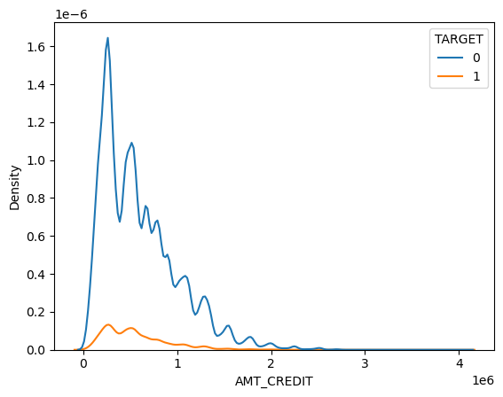

```python
sns.kdeplot(data=num_data,x='AMT_CREDIT', hue='TARGET')
```

most of customers are falling between 0 to 1 million (1e6=million) few of them are defaulters

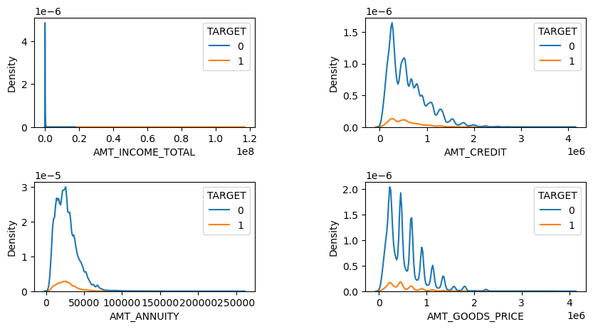

```python
plt.figure(figsize=(10,5))

for i, col in enumerate(amt_var):
    plt.subplot(2,2,i+1)
    sns.kdeplot(data=num_data,x=col,hue='TARGET')
    plt.subplots_adjust(wspace=0.5,hspace=0.5)
```

### ANALYSIS: (Univariate Numeric analysis )

1. Most of the loans were given for the good price ranging between 0 to 1 milion
2. Most of the loans were given for the credit amount of 0 to 1 million
3. Most of the customers are paying annuity of 0 to 50 K
4. Mostly the customers have income between 0 to 1 million

###### BIVARIATE ANALYSIS ON NUMERIC VARIABLES

```python
num_data.head()
```

|  | SK_ID_CURR | TARGET | CNT_CHILDREN | AMT_INCOME_TOTAL | AMT_CREDIT | AMT_ANNUITY | AMT_GOODS_PRICE | REGION_POPULATION_RELATIVE | DAYS_BIRTH | DAYS_EMPLOYED | DAYS_REGISTRATION | DAYS_ID_PUBLISH | CNT_FAM_MEMBERS | REGION_RATING_CLIENT | REGION_RATING_CLIENT_W_CITY | HOUR_APPR_PROCESS_START | REG_REGION_NOT_LIVE_REGION | REG_REGION_NOT_WORK_REGION | LIVE_REGION_NOT_WORK_REGION | REG_CITY_NOT_LIVE_CITY | REG_CITY_NOT_WORK_CITY | LIVE_CITY_NOT_WORK_CITY | OBS_30_CNT_SOCIAL_CIRCLE | DEF_30_CNT_SOCIAL_CIRCLE | OBS_60_CNT_SOCIAL_CIRCLE | DEF_60_CNT_SOCIAL_CIRCLE | DAYS_LAST_PHONE_CHANGE | AMT_REQ_CREDIT_BUREAU_HOUR | AMT_REQ_CREDIT_BUREAU_DAY | … |
| --- | --- | --- | --- | --- | --- | --- | --- | --- | --- | --- | --- | --- | --- | --- | --- | --- | --- | --- | --- | --- | --- | --- | --- | --- | --- | --- | --- | --- | --- | --- |
| 0 | 100002 | 1 | 0 | 202500.0 | 406597.5 | 24700.5 | 351000.0 | 0.018801 | 9461 | 637 | 3648.0 | 2120 | 1.0 | 2 | 2 | 10 | 0 | 0 | 0 | 0 | 0 | 0 | 2.0 | 2.0 | 2.0 | 2.0 | 1134.0 | 0.0 | 0.0 | … |
| 1 | 100003 | 0 | 0 | 270000.0 | 1293502.5 | 35698.5 | 1129500.0 | 0.003541 | 16765 | 1188 | 1186.0 | 291 | 2.0 | 1 | 1 | 11 | 0 | 0 | 0 | 0 | 0 | 0 | 1.0 | 0.0 | 1.0 | 0.0 | 828.0 | 0.0 | 0.0 | … |
| 2 | 100004 | 0 | 0 | 67500.0 | 135000.0 | 6750.0 | 135000.0 | 0.010032 | 19046 | 225 | 4260.0 | 2531 | 1.0 | 2 | 2 | 9 | 0 | 0 | 0 | 0 | 0 | 0 | 0.0 | 0.0 | 0.0 | 0.0 | 815.0 | 0.0 | 0.0 | … |
| 3 | 100006 | 0 | 0 | 135000.0 | 312682.5 | 29686.5 | 297000.0 | 0.008019 | 19005 | 3039 | 9833.0 | 2437 | 2.0 | 2 | 2 | 17 | 0 | 0 | 0 | 0 | 0 | 0 | 2.0 | 0.0 | 2.0 | 0.0 | 617.0 | 0.0 | 0.0 | … |
| 4 | 100007 | 0 | 0 | 121500.0 | 513000.0 | 21865.5 | 513000.0 | 0.028663 | 19932 | 3038 | 4311.0 | 3458 | 1.0 | 2 | 2 | 11 | 0 | 0 | 0 | 0 | 1 | 1 | 0.0 | 0.0 | 0.0 | 0.0 | 1106.0 | 0.0 | 0.0 | … |

what are the relation and how they are influencing to the default behavior by using scatter plot

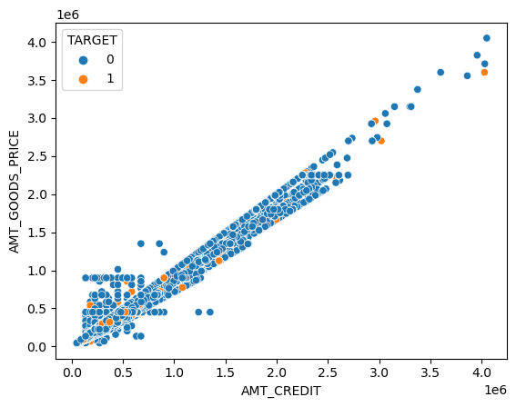

```python
sns.scatterplot(data=num_data,x='AMT_CREDIT',y='AMT_GOODS_PRICE',hue='TARGET')
```

results: Perfect linear relation because if your goods price is higher and if you are getting loan ofcourse along with the goods price your amount credit will also increase

if youre getting a loan amount will be more than the one way where the goods price is less

Bivariate analysis:

1. AMT_CREDIT & AMT_GOODS_PRICE are linearly correlated
2. Most of the defaulters are in the segment of less than 1 million
3. If the AMT_CREDIT increases the Defaulters are decreasing

##### WE NOW will figure out "WHAT SORT OF LOAN AMOUNTS ARE GIVEN TO WHICH INCOME SEGMENT"

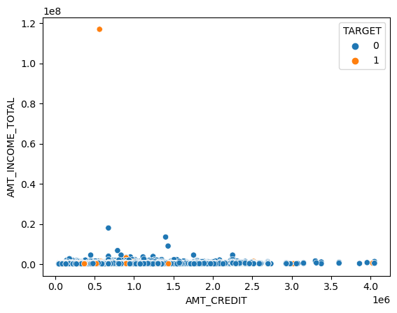

```python
sns.scatterplot(data=num_data,x='AMT_CREDIT',y='AMT_INCOME_TOTAL',hue='TARGET')
```

##### Bivariate analysis:

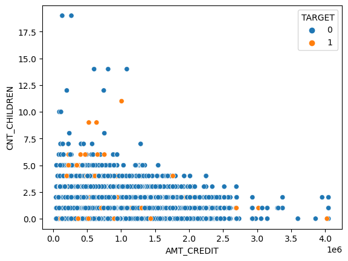

```python
sns.scatterplot(data=num_data,x='AMT_CREDIT',y='CNT_CHILDREN',hue='TARGET')
```

Bivariate analysis:

because if they have kids they will be more responsible so they will pay loans on time and wont default

```python
amt_var = num_data[['AMT_INCOME_TOTAL', 'AMT_CREDIT', 'AMT_ANNUITY', 'AMT_GOODS_PRICE','TARGET']]
```

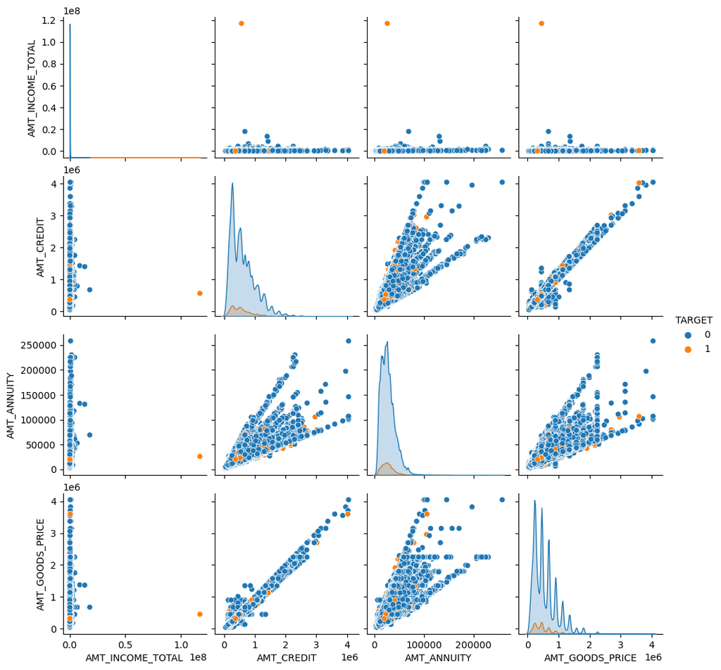

```python
sns.pairplot(data=amt_var,hue='TARGET')
```

Bivariate Analysis:

graph in the middle is the relation between AMT_CREDIT & AMT_ANNUITY and as we see where do we have the density , the most dense area that has multiple dots together (highly densed where people have taken the loan ) so the people who are capable of amount 100k they are getting the loan of somewhere less than or equals to 2M If customer can make more amoutn annuity they can get more amount credit

1. People who can pay the annuity of 100K are more likely to get the loan and that's up to less than 2M SAFER SEGMENT

### EXPLRE PREVIOUS DATASET

```python
# Check null values by %

null_count=pd.DataFrame(prev_app.isnull().sum().sort_values(ascending=False)/prev_app.shape[0]*100).reset_index().rename(columns={'index' : 'var', 0: 'count_pct'})
```

```python
null_count
```

|  | var | count_pct |
| --- | --- | --- |
| 0 | RATE_INTEREST_PRIVILEGED | 99.643698 |
| 1 | RATE_INTEREST_PRIMARY | 99.643698 |
| 2 | AMT_DOWN_PAYMENT | 53.636480 |
| 3 | RATE_DOWN_PAYMENT | 53.636480 |
| 4 | NAME_TYPE_SUITE | 49.119754 |
| 5 | NFLAG_INSURED_ON_APPROVAL | 40.298129 |
| 6 | DAYS_TERMINATION | 40.298129 |
| 7 | DAYS_LAST_DUE | 40.298129 |
| 8 | DAYS_LAST_DUE_1ST_VERSION | 40.298129 |
| 9 | DAYS_FIRST_DUE | 40.298129 |
| 10 | DAYS_FIRST_DRAWING | 40.298129 |
| 11 | AMT_GOODS_PRICE | 23.081773 |
| 12 | AMT_ANNUITY | 22.286665 |
| 13 | CNT_PAYMENT | 22.286366 |
| 14 | PRODUCT_COMBINATION | 0.020716 |
| 15 | AMT_CREDIT | 0.000060 |
| 16 | NAME_YIELD_GROUP | 0.000000 |
| 17 | NAME_PORTFOLIO | 0.000000 |
| 18 | NAME_SELLER_INDUSTRY | 0.000000 |
| 19 | SELLERPLACE_AREA | 0.000000 |
| 20 | CHANNEL_TYPE | 0.000000 |
| 21 | NAME_PRODUCT_TYPE | 0.000000 |
| 22 | SK_ID_PREV | 0.000000 |
| 23 | NAME_GOODS_CATEGORY | 0.000000 |
| 24 | NAME_CLIENT_TYPE | 0.000000 |
| 25 | CODE_REJECT_REASON | 0.000000 |
| 26 | SK_ID_CURR | 0.000000 |
| 27 | DAYS_DECISION | 0.000000 |
| 28 | NAME_CONTRACT_STATUS | 0.000000 |
| 29 | NAME_CASH_LOAN_PURPOSE | 0.000000 |
| 30 | NFLAG_LAST_APPL_IN_DAY | 0.000000 |
| 31 | FLAG_LAST_APPL_PER_CONTRACT | 0.000000 |
| 32 | HOUR_APPR_PROCESS_START | 0.000000 |
| 33 | WEEKDAY_APPR_PROCESS_START | 0.000000 |
| 34 | AMT_APPLICATION | 0.000000 |
| 35 | NAME_CONTRACT_TYPE | 0.000000 |
| 36 | NAME_PAYMENT_TYPE | 0.000000 |

```python
var_msng_ge_40 = list(null_count[null_count['count_pct']>=40]['var'])
var_msng_ge_40
```

```
['RATE_INTEREST_PRIVILEGED',
 'RATE_INTEREST_PRIMARY',
 'AMT_DOWN_PAYMENT',
 'RATE_DOWN_PAYMENT',
 'NAME_TYPE_SUITE',
 'NFLAG_INSURED_ON_APPROVAL',
 'DAYS_TERMINATION',
 'DAYS_LAST_DUE',
 'DAYS_LAST_DUE_1ST_VERSION',
 'DAYS_FIRST_DUE',
 'DAYS_FIRST_DRAWING']
```

These are the columns which have null values greater than 40%

while reading column descrption i figured out that these columns arent much important or used :

1. WEEKDAY_APPR_PROCESS_START
2. HOUR_APPR_PROCESS_START
3. FLAG_LAST_APPL_PER_CONTRACT
4. NFLAG_LAST_APPL_IN_DAY

so now we will combine these with the upper variables we'll drop and drop them all

```python
# Non- Valuable Columns

nva_cols=var_msng_ge_40+['WEEKDAY_APPR_PROCESS_START','HOUR_APPR_PROCESS_START','FLAG_LAST_APPL_PER_CONTRACT','NFLAG_LAST_APPL_IN_DAY']

len(nva_cols)
```

```
15
```

```python
nva_cols
```

```
['RATE_INTEREST_PRIVILEGED',
 'RATE_INTEREST_PRIMARY',
 'AMT_DOWN_PAYMENT',
 'RATE_DOWN_PAYMENT',
 'NAME_TYPE_SUITE',
 'NFLAG_INSURED_ON_APPROVAL',
 'DAYS_TERMINATION',
 'DAYS_LAST_DUE',
 'DAYS_LAST_DUE_1ST_VERSION',
 'DAYS_FIRST_DUE',
 'DAYS_FIRST_DRAWING',
 'WEEKDAY_APPR_PROCESS_START',
 'HOUR_APPR_PROCESS_START',
 'FLAG_LAST_APPL_PER_CONTRACT',
 'NFLAG_LAST_APPL_IN_DAY']
```

```python
len(prev_app.columns)
```

```
37
```

```python
prev_app_nva_col_rmvd = prev_app.drop(labels=nva_cols,axis=1)

len(prev_app_nva_col_rmvd.columns)
```

```
22
```

```python
prev_app_nva_col_rmvd.columns
```

```
Index(['SK_ID_PREV', 'SK_ID_CURR', 'NAME_CONTRACT_TYPE', 'AMT_ANNUITY',
       'AMT_APPLICATION', 'AMT_CREDIT', 'AMT_GOODS_PRICE',
       'NAME_CASH_LOAN_PURPOSE', 'NAME_CONTRACT_STATUS', 'DAYS_DECISION',
       'NAME_PAYMENT_TYPE', 'CODE_REJECT_REASON', 'NAME_CLIENT_TYPE',
       'NAME_GOODS_CATEGORY', 'NAME_PORTFOLIO', 'NAME_PRODUCT_TYPE',
       'CHANNEL_TYPE', 'SELLERPLACE_AREA', 'NAME_SELLER_INDUSTRY',
       'CNT_PAYMENT', 'NAME_YIELD_GROUP', 'PRODUCT_COMBINATION'],
      dtype='object')
```

```python
prev_app_nva_col_rmvd.head()
```

|  | SK_ID_PREV | SK_ID_CURR | NAME_CONTRACT_TYPE | AMT_ANNUITY | AMT_APPLICATION | AMT_CREDIT | AMT_GOODS_PRICE | NAME_CASH_LOAN_PURPOSE | NAME_CONTRACT_STATUS | DAYS_DECISION | NAME_PAYMENT_TYPE | CODE_REJECT_REASON | NAME_CLIENT_TYPE | NAME_GOODS_CATEGORY | NAME_PORTFOLIO | NAME_PRODUCT_TYPE | CHANNEL_TYPE | SELLERPLACE_AREA | NAME_SELLER_INDUSTRY | CNT_PAYMENT | NAME_YIELD_GROUP | PRODUCT_COMBINATION |
| --- | --- | --- | --- | --- | --- | --- | --- | --- | --- | --- | --- | --- | --- | --- | --- | --- | --- | --- | --- | --- | --- | --- |
| 0 | 2030495 | 271877 | Consumer loans | 1730.430 | 17145.0 | 17145.0 | 17145.0 | XAP | Approved | -73 | Cash through the bank | XAP | Repeater | Mobile | POS | XNA | Country-wide | 35 | Connectivity | 12.0 | middle | POS mobile with interest |
| 1 | 2802425 | 108129 | Cash loans | 25188.615 | 607500.0 | 679671.0 | 607500.0 | XNA | Approved | -164 | XNA | XAP | Repeater | XNA | Cash | x-sell | Contact center | -1 | XNA | 36.0 | low_action | Cash X-Sell: low |
| 2 | 2523466 | 122040 | Cash loans | 15060.735 | 112500.0 | 136444.5 | 112500.0 | XNA | Approved | -301 | Cash through the bank | XAP | Repeater | XNA | Cash | x-sell | Credit and cash offices | -1 | XNA | 12.0 | high | Cash X-Sell: high |
| 3 | 2819243 | 176158 | Cash loans | 47041.335 | 450000.0 | 470790.0 | 450000.0 | XNA | Approved | -512 | Cash through the bank | XAP | Repeater | XNA | Cash | x-sell | Credit and cash offices | -1 | XNA | 12.0 | middle | Cash X-Sell: middle |
| 4 | 1784265 | 202054 | Cash loans | 31924.395 | 337500.0 | 404055.0 | 337500.0 | Repairs | Refused | -781 | Cash through the bank | HC | Repeater | XNA | Cash | walk-in | Credit and cash offices | -1 | XNA | 24.0 | high | Cash Street: high |

```python
prev_app_nva_col_rmvd.isnull().sum().sort_values(ascending=False)/prev_app_nva_col_rmvd.shape[0]*100
```

```
AMT_GOODS_PRICE           23.081773
AMT_ANNUITY               22.286665
CNT_PAYMENT               22.286366
PRODUCT_COMBINATION        0.020716
AMT_CREDIT                 0.000060
NAME_GOODS_CATEGORY        0.000000
NAME_YIELD_GROUP           0.000000
NAME_SELLER_INDUSTRY       0.000000
SELLERPLACE_AREA           0.000000
CHANNEL_TYPE               0.000000
NAME_PRODUCT_TYPE          0.000000
NAME_PORTFOLIO             0.000000
SK_ID_PREV                 0.000000
NAME_CLIENT_TYPE           0.000000
SK_ID_CURR                 0.000000
NAME_PAYMENT_TYPE          0.000000
DAYS_DECISION              0.000000
NAME_CONTRACT_STATUS       0.000000
NAME_CASH_LOAN_PURPOSE     0.000000
AMT_APPLICATION            0.000000
NAME_CONTRACT_TYPE         0.000000
CODE_REJECT_REASON         0.000000
dtype: float64
```

```python
# Analyzing the AMT_GOODS_PRICE
prev_app_nva_col_rmvd['AMT_GOODS_PRICE'].agg(func=['mean','median'])
```

```
mean      227847.279283
median    112320.000000
Name: AMT_GOODS_PRICE, dtype: float64
```

1. 50% of loans have good price
2. There are outliers because mean and median are completely different

```python
# I'm creating a variable using median
prev_app_nva_col_rmvd['AMT_GOODS_PRICE_MEDIAN'] = prev_app_nva_col_rmvd['AMT_GOODS_PRICE'].fillna(prev_app_nva_col_rmvd['AMT_GOODS_PRICE'].median())
```

```python
 # I'm creating a variable using mean
prev_app_nva_col_rmvd['AMT_GOODS_PRICE_MEAN'] = prev_app_nva_col_rmvd['AMT_GOODS_PRICE'].fillna(prev_app_nva_col_rmvd['AMT_GOODS_PRICE'].mean())
```

```python
# I'm creating a variable using mode
prev_app_nva_col_rmvd['AMT_GOODS_PRICE_MODE'] = prev_app_nva_col_rmvd['AMT_GOODS_PRICE'].fillna(prev_app_nva_col_rmvd['AMT_GOODS_PRICE'].mode()[0])
```

```python
gp_cols=['AMT_GOODS_PRICE','AMT_GOODS_PRICE_MEDIAN','AMT_GOODS_PRICE_MEAN','AMT_GOODS_PRICE_MODE']
```

I am trying to figure out the best way to fill the missing values

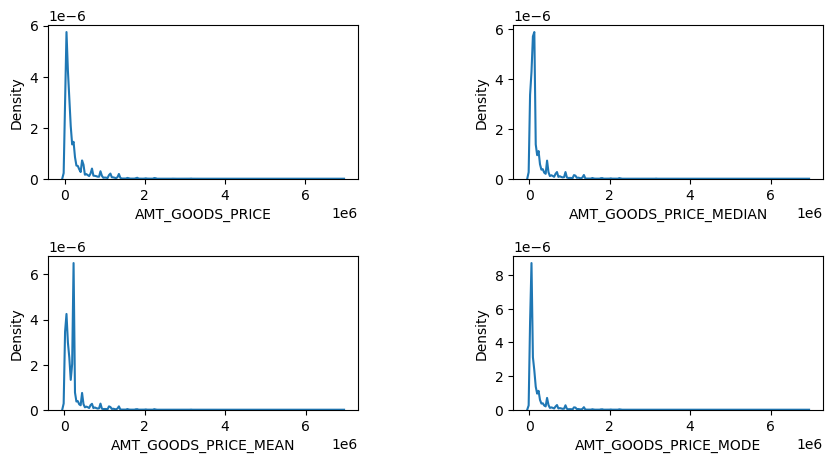

```python
plt.figure(figsize=(10,5))

for i , col in enumerate(gp_cols):
    plt.subplot(2,2,i+1)
    sns.kdeplot(data=prev_app_nva_col_rmvd,x=col)
    plt.subplots_adjust(wspace=0.5,hspace=0.5)
```

1. Mean is out of scope as its different
2. Median looks pretty identical
3. Mode isnt exactly

so i'll go ahead and use median

```python
# I'm creating a variable using median
prev_app_nva_col_rmvd['AMT_GOODS_PRICE'] = prev_app_nva_col_rmvd['AMT_GOODS_PRICE'].fillna(prev_app_nva_col_rmvd['AMT_GOODS_PRICE'].median())
```

```python
prev_app_nva_col_rmvd['AMT_GOODS_PRICE'].isnull().sum()
```

```
0
```

```python
# AMT_ANNUITY = IS THE ANNUAL PAYEMENT WHICH THE CUSTOMER CAN MAKE
prev_app_nva_col_rmvd['AMT_ANNUITY'].agg(func=['mean','median','max'])
```

```
mean       15955.120659
median     11250.000000
max       418058.145000
Name: AMT_ANNUITY, dtype: float64
```

```python
prev_app_nva_col_rmvd['AMT_ANNUITY'] = prev_app_nva_col_rmvd['AMT_ANNUITY'].fillna(prev_app_nva_col_rmvd['AMT_ANNUITY'].median())
```

```python
prev_app_nva_col_rmvd['AMT_ANNUITY'].isnull().sum()
```

```
0
```

```python
prev_app_nva_col_rmvd['PRODUCT_COMBINATION'].head()
```

```
0    POS mobile with interest
1            Cash X-Sell: low
2           Cash X-Sell: high
3         Cash X-Sell: middle
4           Cash Street: high
Name: PRODUCT_COMBINATION, dtype: object
```

```python
prev_app_nva_col_rmvd['PRODUCT_COMBINATION'] = prev_app_nva_col_rmvd['PRODUCT_COMBINATION'].fillna(prev_app_nva_col_rmvd['PRODUCT_COMBINATION'].mode()[0])
```

```python
prev_app_nva_col_rmvd['PRODUCT_COMBINATION'].isnull().sum()
```

```
0
```

```python
# CNT_PAYEMENT = For how many months the loan was given

prev_app_nva_col_rmvd['CNT_PAYMENT'].agg(func=['mean','median','max'])
```

```
mean      16.054082
median    12.000000
max       84.000000
Name: CNT_PAYMENT, dtype: float64
```

```python
prev_app_nva_col_rmvd[prev_app_nva_col_rmvd['CNT_PAYMENT'].isnull()].groupby(['NAME_CONTRACT_STATUS']).size().sort_values(ascending=False)
```

```
NAME_CONTRACT_STATUS
Canceled        305805
Refused          40897
Unused offer     25524
Approved             4
dtype: int64
```

1. Majority of applications are getting cancelled which mean , median , max will affect the data and have significant contribution, which won't make sense
2. Most importantly cancelled is something which is going to be non-valuable, so i'll use 0 to fill values

```python
prev_app_nva_col_rmvd['CNT_PAYMENT'] = prev_app_nva_col_rmvd['CNT_PAYMENT'].fillna(0)
```

```python
prev_app_nva_col_rmvd.isnull().sum().sort_values(ascending=False)
```

```
AMT_CREDIT                1
SK_ID_PREV                0
NAME_GOODS_CATEGORY       0
AMT_GOODS_PRICE_MEAN      0
AMT_GOODS_PRICE_MEDIAN    0
PRODUCT_COMBINATION       0
NAME_YIELD_GROUP          0
CNT_PAYMENT               0
NAME_SELLER_INDUSTRY      0
SELLERPLACE_AREA          0
CHANNEL_TYPE              0
NAME_PRODUCT_TYPE         0
NAME_PORTFOLIO            0
NAME_CLIENT_TYPE          0
SK_ID_CURR                0
CODE_REJECT_REASON        0
NAME_PAYMENT_TYPE         0
DAYS_DECISION             0
NAME_CONTRACT_STATUS      0
NAME_CASH_LOAN_PURPOSE    0
AMT_GOODS_PRICE           0
AMT_APPLICATION           0
AMT_ANNUITY               0
NAME_CONTRACT_TYPE        0
AMT_GOODS_PRICE_MODE      0
dtype: int64
```

```python
prev_app_nva_col_rmvd= prev_app_nva_col_rmvd.drop(labels= ['AMT_GOODS_PRICE_MEDIAN','AMT_GOODS_PRICE_MEAN','AMT_GOODS_PRICE_MODE'],axis=1)
```

```python
prev_app_nva_col_rmvd.isnull().sum().sort_values(ascending=False)
```

```
AMT_CREDIT                1
SK_ID_PREV                0
NAME_CLIENT_TYPE          0
NAME_YIELD_GROUP          0
CNT_PAYMENT               0
NAME_SELLER_INDUSTRY      0
SELLERPLACE_AREA          0
CHANNEL_TYPE              0
NAME_PRODUCT_TYPE         0
NAME_PORTFOLIO            0
NAME_GOODS_CATEGORY       0
CODE_REJECT_REASON        0
SK_ID_CURR                0
NAME_PAYMENT_TYPE         0
DAYS_DECISION             0
NAME_CONTRACT_STATUS      0
NAME_CASH_LOAN_PURPOSE    0
AMT_GOODS_PRICE           0
AMT_APPLICATION           0
AMT_ANNUITY               0
NAME_CONTRACT_TYPE        0
PRODUCT_COMBINATION       0
dtype: int64
```

```python
len(prev_app_nva_col_rmvd.columns)
```

```
22
```

### MERGE BOTH APP & PREVIOUS DATASET

```python
merged_df = pd.merge(app_score_col_rmvd,prev_app_nva_col_rmvd,how='inner',on='SK_ID_CURR')
merged_df.head()
```

|  | SK_ID_CURR | TARGET | NAME_CONTRACT_TYPE_x | CODE_GENDER | CNT_CHILDREN | AMT_INCOME_TOTAL | AMT_CREDIT_x | AMT_ANNUITY_x | AMT_GOODS_PRICE_x | NAME_TYPE_SUITE | NAME_INCOME_TYPE | NAME_EDUCATION_TYPE | NAME_FAMILY_STATUS | NAME_HOUSING_TYPE | REGION_POPULATION_RELATIVE | DAYS_BIRTH | DAYS_EMPLOYED | DAYS_REGISTRATION | DAYS_ID_PUBLISH | OCCUPATION_TYPE | CNT_FAM_MEMBERS | REGION_RATING_CLIENT | REGION_RATING_CLIENT_W_CITY | WEEKDAY_APPR_PROCESS_START | HOUR_APPR_PROCESS_START | REG_REGION_NOT_LIVE_REGION | REG_REGION_NOT_WORK_REGION | LIVE_REGION_NOT_WORK_REGION | REG_CITY_NOT_LIVE_CITY | … |
| --- | --- | --- | --- | --- | --- | --- | --- | --- | --- | --- | --- | --- | --- | --- | --- | --- | --- | --- | --- | --- | --- | --- | --- | --- | --- | --- | --- | --- | --- | --- |
| 0 | 100002 | 1 | Cash loans | M | 0 | 202500.0 | 406597.5 | 24700.5 | 351000.0 | Unaccompanied | Working | Secondary / secondary special | Single / not married | House / apartment | 0.018801 | 9461 | 637 | 3648.0 | 2120 | Laborers | 1.0 | 2 | 2 | WEDNESDAY | 10 | 0 | 0 | 0 | 0 | … |
| 1 | 100003 | 0 | Cash loans | F | 0 | 270000.0 | 1293502.5 | 35698.5 | 1129500.0 | Family | State servant | Higher education | Married | House / apartment | 0.003541 | 16765 | 1188 | 1186.0 | 291 | Core staff | 2.0 | 1 | 1 | MONDAY | 11 | 0 | 0 | 0 | 0 | … |
| 2 | 100003 | 0 | Cash loans | F | 0 | 270000.0 | 1293502.5 | 35698.5 | 1129500.0 | Family | State servant | Higher education | Married | House / apartment | 0.003541 | 16765 | 1188 | 1186.0 | 291 | Core staff | 2.0 | 1 | 1 | MONDAY | 11 | 0 | 0 | 0 | 0 | … |
| 3 | 100003 | 0 | Cash loans | F | 0 | 270000.0 | 1293502.5 | 35698.5 | 1129500.0 | Family | State servant | Higher education | Married | House / apartment | 0.003541 | 16765 | 1188 | 1186.0 | 291 | Core staff | 2.0 | 1 | 1 | MONDAY | 11 | 0 | 0 | 0 | 0 | … |
| 4 | 100004 | 0 | Revolving loans | M | 0 | 67500.0 | 135000.0 | 6750.0 | 135000.0 | Unaccompanied | Working | Secondary / secondary special | Single / not married | House / apartment | 0.010032 | 19046 | 225 | 4260.0 | 2531 | Laborers | 1.0 | 2 | 2 | MONDAY | 9 | 0 | 0 | 0 | 0 | … |

I'll use from PREVIOUS_APP: NAME_CONTRACT_STATUS , TARGET , NAME_CASH_LOAN_PURPOSE (primary focus )

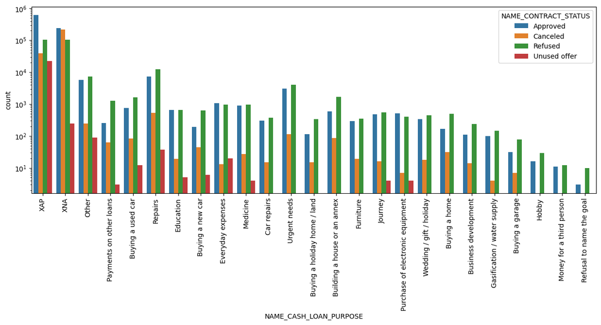

```python
plt.figure(figsize=(15,5))

sns.countplot(data=merged_df,x='NAME_CASH_LOAN_PURPOSE',hue='NAME_CONTRACT_STATUS')
plt.xticks(rotation=90)
plt.yscale('log')
```

#### WHAT HAPPENED WHEN CUSTOMER APPLIED AGAIN?

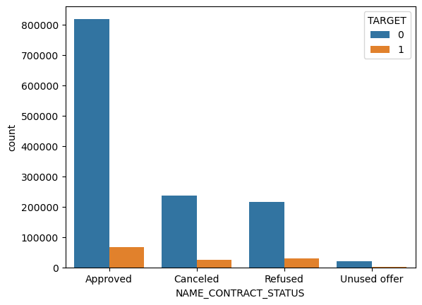

```python
sns.countplot(data=merged_df,x='NAME_CONTRACT_STATUS',hue='TARGET')
```

Previously the application who were cancelled or refused , 90% of them are turning out to be repaired , so it's not necessary to customer cancelled or refused is defaulter

1. Most of the applications which was previously either cancelled or refused , 80%-90% are repaired in current data

```python
merged_agg= merged_df.groupby(['NAME_CONTRACT_STATUS','TARGET']).size().reset_index().rename(columns={0:'counts'})
merged_agg
```

|  | NAME_CONTRACT_STATUS | TARGET | counts |
| --- | --- | --- | --- |
| 0 | Approved | 0 | 818856 |
| 1 | Approved | 1 | 67243 |
| 2 | Canceled | 0 | 235641 |
| 3 | Canceled | 1 | 23800 |
| 4 | Refused | 0 | 215952 |
| 5 | Refused | 1 | 29438 |
| 6 | Unused offer | 0 | 20892 |
| 7 | Unused offer | 1 | 1879 |

```python
sum_df= merged_agg.groupby(['NAME_CONTRACT_STATUS'])['counts'].sum().reset_index()
sum_df
```

|  | NAME_CONTRACT_STATUS | counts |
| --- | --- | --- |
| 0 | Approved | 886099 |
| 1 | Canceled | 259441 |
| 2 | Refused | 245390 |
| 3 | Unused offer | 22771 |

```python
merged_agg_2= pd.merge(merged_agg,sum_df,how='left',on='NAME_CONTRACT_STATUS')
merged_agg_2
```

|  | NAME_CONTRACT_STATUS | TARGET | counts_x | counts_y |
| --- | --- | --- | --- | --- |
| 0 | Approved | 0 | 818856 | 886099 |
| 1 | Approved | 1 | 67243 | 886099 |
| 2 | Canceled | 0 | 235641 | 259441 |
| 3 | Canceled | 1 | 23800 | 259441 |
| 4 | Refused | 0 | 215952 | 245390 |
| 5 | Refused | 1 | 29438 | 245390 |
| 6 | Unused offer | 0 | 20892 | 22771 |
| 7 | Unused offer | 1 | 1879 | 22771 |

i merged both together to divide and get the percentage

```python
merged_agg_2['pct'] = round(merged_agg_2['counts_x']/merged_agg_2['counts_y']*100,2)
```

```python
merged_agg_2
```

|  | NAME_CONTRACT_STATUS | TARGET | counts_x | counts_y | pct |
| --- | --- | --- | --- | --- | --- |
| 0 | Approved | 0 | 818856 | 886099 | 92.41 |
| 1 | Approved | 1 | 67243 | 886099 | 7.59 |
| 2 | Canceled | 0 | 235641 | 259441 | 90.83 |
| 3 | Canceled | 1 | 23800 | 259441 | 9.17 |
| 4 | Refused | 0 | 215952 | 245390 | 88.00 |
| 5 | Refused | 1 | 29438 | 245390 | 12.00 |
| 6 | Unused offer | 0 | 20892 | 22771 | 91.75 |
| 7 | Unused offer | 1 | 1879 | 22771 | 8.25 |

1. 90.83 % = REPAIRED
2. 9.17 % = DEFAULTER
3. 88 % = REPAIRED
4. 12 % = DEFAULTER

90% of customers seems to be repaired

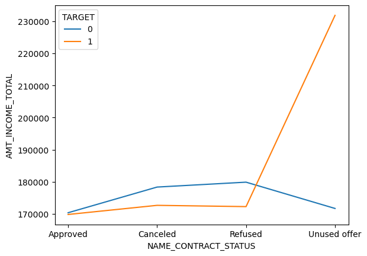

```python
sns.lineplot(data=merged_df,x='NAME_CONTRACT_STATUS',y='AMT_INCOME_TOTAL',ci=None,hue='TARGET')
```

```python
len(merged_df.columns)
```

```
70
```

# Conclusion / Insights

1. Most of customers have taken cash loan
2. Customers who have taken cash loans are less likely to default

#### Recommendation: We can recommend a bank to focus on giving the cash loan to the customers

</br>

#### CODE_GENDER -

1. Most of loans have been taken by female
2. Default rate for females are just 7% which is safer and less than male </br>

#### NAME_TYPE_SUITE -

1. Unacompained people have taken most of loans and the default rate is 8.5% which is still okay

</br>

#### NAME_INCOME_TYPE -

1. 1. The safest segments are working , commercial associates and pensioners

</br>

#### NAME_EDUCATION_TYPE -

1. Higher education is the safest segment to give the loan with a default rate of less than 5%

</br>

#### NAME_FAMILY_STATUS -

1. Married people are safe target , default rate is 8%

</br>

#### NAME_HOUSING_TYPE -

1. People having house/appartement are safe to give the loan with default rate of 8%

</br>

#### OCCUPATION_TYPE -

1. Low skill laborers and drivers are highest defaulters
2. Accountants are less defaulters
3. Core staff, Managers, and Laborers are safer to target with a default rate of <=7.5 to 10%

#### ORGANIZATION_TYPE -

1. Transport type 3 highest defaulter
2. Others, Buisness entity type 3 , Self employes are good to go with default rate around 10%

## Univariate Numeric Variables Analysis

1. Most of the loans are given the goods price ranging between 0 to 1 million
2. Most of the loans were given for the credit amount of 0 to 1 ml
3. Most of the customers are paying annuity of 0 to 50K
4. Mostly the customers have income between 0 to 1 ml

</br></br>

## Bivariate Analysis

1. AMT_CREDIT & AMT_GOODS_PRICE are linearly correlated , if the AMT_CREDIT increases the defaulters are decreasing
2. People having income less than or equal 1 ml are more likely to take loans out of which who are taking loan of less than 1.5 ml , could turn out to be defaulter , we can target income below 1 million and loan amount greater than 1.5 million
3. People having children 1 to less than 5 are safer to give the loan
4. People who can pay the annuity of 100K are more like to get the loan and that's up to less than 2 million (safer segment)

</br></br>

## Recommendation:

#### 1. Banks should target the customers -

```
1. Having low income
2. Working in Others,Buisness Entity Type 3, Self Employes org. type
3. Working as Accountants , Core staff, Managers, and Laborers
4. Having house/appartement and are married and having children not more than 5
5. Highly educated
6. Preferably females
```

#### 2. Unaccopmaied people can be safer - default rate 8.5%

#### 3. Amount segment recommended -

```
1. The credit amount should NOT be more than 1 ml
2. Annuity can be made of 50K (depending on the eligibilty)
3. Income bracket could be below 1 million
```

#### 4. 80-90% of the customers who were prev. cancelled / refused are repayers , Bank can do the analysis and can consider to give loan to these segments

## Precautions :

1. Organization tyoe 3 should be avoided (as mentioned transport type 3 has highest defaulter)
2. Low-Skill laborers should be avoided
3. Offers prev. unused & high income customer should be avoided